# Prediction On Resale Flat Price

References:

1. https://statsandr.com/blog/descriptive-statistics-in-r/  
2. https://towardsdatascience.com/data-cleaning-with-r-and-the-tidyverse-detecting-missing-values-ea23c519bc62  
3. https://rstudio-pubs-static.s3.amazonaws.com/3364_d1a578f521174152b46b19d0c83cbe7e.html  
4. https://medium.com/data-science-in-your-pocket/various-data-distributions-in-statistics-362dc92558db  
5. https://stackoverflow.com/questions/5570293/add-column-which-contains-binned-values-of-an-integer-column

## Import Libraries

```r
library(tidyr)
library(tidyverse)
library(summarytools)
library(dlookr)
library(ggplot2)
library(plyr)
```

# Data Cleaning

## Read CSV

```r
data_2015_2016 <- read.csv("../data/resale-flat-prices-based-on-registration-date-from-jan-2015-to-dec-2016.csv", header = TRUE, sep = ",")
data_2017 <- read.csv("../data/resale-flat-prices-based-on-registration-date-from-jan-2017-onwards.csv", header = TRUE, sep = ",")

data_info <- read.csv("../data/hdb-property-information.csv", header = TRUE, sep = ",")
```

## Data Columns Exploration

```r
print("data_2015_2016:")
```

```
[1] "data_2015_2016:"
```

```r
str(data_2015_2016)
```

```
'data.frame':   37153 obs. of  11 variables:
 $ month              : chr  "2015-01" "2015-01" "2015-01" "2015-01" ...
 $ town               : chr  "ANG MO KIO" "ANG MO KIO" "ANG MO KIO" "ANG MO KIO" ...
 $ flat_type          : chr  "3 ROOM" "3 ROOM" "3 ROOM" "3 ROOM" ...
 $ block              : chr  "174" "541" "163" "446" ...
 $ street_name        : chr  "ANG MO KIO AVE 4" "ANG MO KIO AVE 10" "ANG MO KIO AVE 4" "ANG MO KIO AVE 10" ...
 $ storey_range       : chr  "07 TO 09" "01 TO 03" "01 TO 03" "01 TO 03" ...
 $ floor_area_sqm     : num  60 68 69 68 68 67 68 68 67 68 ...
 $ flat_model         : chr  "Improved" "New Generation" "New Generation" "New Generation" ...
 $ lease_commence_date: int  1986 1981 1980 1979 1980 1980 1980 1981 1978 1985 ...
 $ remaining_lease    : int  70 65 64 63 64 64 64 65 62 69 ...
 $ resale_price       : num  255000 275000 285000 290000 290000 ...
```

```r
print("data_2017:")
```

```
[1] "data_2017:"
```

```r
str(data_2017)
```

```
'data.frame':   115302 obs. of  11 variables:
 $ month              : chr  "2017-01" "2017-01" "2017-01" "2017-01" ...
 $ town               : chr  "ANG MO KIO" "ANG MO KIO" "ANG MO KIO" "ANG MO KIO" ...
 $ flat_type          : chr  "2 ROOM" "3 ROOM" "3 ROOM" "3 ROOM" ...
 $ block              : chr  "406" "108" "602" "465" ...
 $ street_name        : chr  "ANG MO KIO AVE 10" "ANG MO KIO AVE 4" "ANG MO KIO AVE 5" "ANG MO KIO AVE 10" ...
 $ storey_range       : chr  "10 TO 12" "01 TO 03" "01 TO 03" "04 TO 06" ...
 $ floor_area_sqm     : num  44 67 67 68 67 68 68 67 68 67 ...
 $ flat_model         : chr  "Improved" "New Generation" "New Generation" "New Generation" ...
 $ lease_commence_date: int  1979 1978 1980 1980 1980 1981 1979 1976 1979 1979 ...
 $ remaining_lease    : chr  "61 years 04 months" "60 years 07 months" "62 years 05 months" "62 years 01 month" ...
 $ resale_price       : num  232000 250000 262000 265000 265000 275000 280000 285000 285000 285000 ...
```

```r
print("data_info:")
```

```
[1] "data_info:"
```

```r
str(data_info)
```

```
'data.frame':   12442 obs. of  24 variables:
 $ blk_no               : chr  "1" "1" "1" "1" ...
 $ street               : chr  "BEACH RD" "BEDOK STH AVE 1" "CANTONMENT RD" "CHAI CHEE RD" ...
 $ max_floor_lvl        : int  16 14 2 15 4 25 12 14 12 2 ...
 $ year_completed       : int  1970 1975 2010 1982 1975 1982 1975 1977 1980 2009 ...
 $ residential          : chr  "Y" "Y" "N" "Y" ...
 $ commercial           : chr  "Y" "N" "Y" "N" ...
 $ market_hawker        : chr  "N" "N" "N" "N" ...
 $ miscellaneous        : chr  "N" "Y" "N" "N" ...
 $ multistorey_carpark  : chr  "N" "N" "N" "N" ...
 $ precinct_pavilion    : chr  "N" "N" "N" "N" ...
 $ bldg_contract_town   : chr  "KWN" "BD" "CT" "BD" ...
 $ total_dwelling_units : int  142 206 0 102 55 96 125 247 95 0 ...
 $ X1room_sold          : int  0 0 0 0 0 0 0 0 0 0 ...
 $ X2room_sold          : int  1 0 0 0 0 0 0 0 0 0 ...
 $ X3room_sold          : int  138 204 0 0 54 0 118 0 62 0 ...
 $ X4room_sold          : int  1 0 0 10 0 0 0 0 0 0 ...
 $ X5room_sold          : int  2 2 0 92 1 96 7 0 33 0 ...
 $ exec_sold            : int  0 0 0 0 0 0 0 0 0 0 ...
 $ multigen_sold        : int  0 0 0 0 0 0 0 0 0 0 ...
 $ studio_apartment_sold: int  0 0 0 0 0 0 0 0 0 0 ...
 $ X1room_rental        : int  0 0 0 0 0 0 0 0 0 0 ...
 $ X2room_rental        : int  0 0 0 0 0 0 0 247 0 0 ...
 $ X3room_rental        : int  0 0 0 0 0 0 0 0 0 0 ...
 $ other_room_rental    : int  0 0 0 0 0 0 0 0 0 0 ...
```

## Data Preprocessing Before Data Integration

Transform the remaining lease to month for data_2015_2016.

```r
data_2015_2016$remaining_lease <- data_2015_2016$remaining_lease * 12
str(data_2015_2016$remaining_lease)
```

```
 num [1:37153] 840 780 768 756 768 768 768 780 744 828 ...
```

Transform the remaining lease to month for data_2017.

```r
convert_remaining_lease <- function(remaining_lease) {
  lease <- trimws(remaining_lease)
  year <- substr(lease, 0, 2)


  result <- ifelse(grepl("month", lease), as.integer(year) * 12 + as.integer(substr(lease, 9, 11)) , as.integer(year) * 12)
  return(result)
}

data_2017$remaining_lease <- convert_remaining_lease(data_2017$remaining_lease)
str(data_2017$remaining_lease)
```

```
 num [1:115302] 736 727 749 745 749 756 738 700 738 736 ...
```

Drop columns from data_info that are not contributing for resale price prediction.

```r
data_info <- data_info %>% select(c("bldg_contract_town", "street", "blk_no", "max_floor_lvl", "commercial", "market_hawker", "miscellaneous", "multistorey_carpark", "precinct_pavilion"))
str(data_info)
```

```
'data.frame':   12442 obs. of  9 variables:
 $ bldg_contract_town : chr  "KWN" "BD" "CT" "BD" ...
 $ street             : chr  "BEACH RD" "BEDOK STH AVE 1" "CANTONMENT RD" "CHAI CHEE RD" ...
 $ blk_no             : chr  "1" "1" "1" "1" ...
 $ max_floor_lvl      : int  16 14 2 15 4 25 12 14 12 2 ...
 $ commercial         : chr  "Y" "N" "Y" "N" ...
 $ market_hawker      : chr  "N" "N" "N" "N" ...
 $ miscellaneous      : chr  "N" "Y" "N" "N" ...
 $ multistorey_carpark: chr  "N" "N" "N" "N" ...
 $ precinct_pavilion  : chr  "N" "N" "N" "N" ...
```

Convert Y/N to binary.

```r
data_info$commercial <- ifelse(data_info$commercial == "Y", 1, 0)
data_info$market_hawker <- ifelse(data_info$market_hawker == "Y", 1, 0)
data_info$miscellaneous <- ifelse(data_info$miscellaneous == "Y", 1, 0)
data_info$multistorey_carpark <- ifelse(data_info$multistorey_carpark == "Y", 1, 0)
data_info$precinct_pavilion <- ifelse(data_info$precinct_pavilion == "Y", 1, 0)

str(data_info)
```

```
'data.frame':   12442 obs. of  9 variables:
 $ bldg_contract_town : chr  "KWN" "BD" "CT" "BD" ...
 $ street             : chr  "BEACH RD" "BEDOK STH AVE 1" "CANTONMENT RD" "CHAI CHEE RD" ...
 $ blk_no             : chr  "1" "1" "1" "1" ...
 $ max_floor_lvl      : int  16 14 2 15 4 25 12 14 12 2 ...
 $ commercial         : num  1 0 1 0 1 0 0 0 1 1 ...
 $ market_hawker      : num  0 0 0 0 0 0 0 0 0 0 ...
 $ miscellaneous      : num  0 1 0 0 0 0 1 1 0 0 ...
 $ multistorey_carpark: num  0 0 0 0 0 0 0 0 0 0 ...
 $ precinct_pavilion  : num  0 0 0 0 0 0 0 0 0 0 ...
```

Convert town in short form to full text

```r
town_short <- c("AMK","BB","BD","BH","BM","BP","BT","CCK","CL","CT","GL","HG","JE","JW","KWN","MP","PG","PRC","QT","SB","SGN","SK","TAP","TG","TP","WL","YS")
town_full <- c( "ANG MO KIO","BUKIT BATOK","BEDOK","BISHAN","BUKIT MERAH","BUKIT PANJANG","BUKIT TIMAH","CHOA CHU KANG","CLEMENTI","CENTRAL AREA","GEYLANG","HOUGANG","JURONG EAST","JURONG WEST","KALLANG/WHAMPOA","MARINE PARADE","PUNGGOL","PASIR RIS","QUEENSTOWN","SEMBAWANG","SERANGOON","SENGKANG","TAMPINES","TENGAH","TOA PAYOH","WOODLANDS","YISHUN")

data_info$bldg_contract_town <- mapvalues(data_info$bldg_contract_town, from=town_short, to=town_full)
str(data_info$bldg_contract_town)
```

```
 chr [1:12442] "KALLANG/WHAMPOA" "BEDOK" "CENTRAL AREA" "BEDOK" "PASIR RIS" "BUKIT MERAH" "QUEENSTOWN" "GEYLANG" ...
```

```r
unique(sort(data_info$bldg_contract_town))
```

```
 [1] "ANG MO KIO"      "BEDOK"           "BISHAN"          "BUKIT BATOK"     "BUKIT MERAH"     "BUKIT PANJANG"
 [7] "BUKIT TIMAH"     "CENTRAL AREA"    "CHOA CHU KANG"   "CLEMENTI"        "GEYLANG"         "HOUGANG"
[13] "JURONG EAST"     "JURONG WEST"     "KALLANG/WHAMPOA" "MARINE PARADE"   "PASIR RIS"       "PUNGGOL"
[19] "QUEENSTOWN"      "SEMBAWANG"       "SENGKANG"        "SERANGOON"       "TAMPINES"        "TOA PAYOH"
[25] "WOODLANDS"       "YISHUN"
```

```r
unique(sort(data_2015_2016$town))
```

```
 [1] "ANG MO KIO"      "BEDOK"           "BISHAN"          "BUKIT BATOK"     "BUKIT MERAH"     "BUKIT PANJANG"
 [7] "BUKIT TIMAH"     "CENTRAL AREA"    "CHOA CHU KANG"   "CLEMENTI"        "GEYLANG"         "HOUGANG"
[13] "JURONG EAST"     "JURONG WEST"     "KALLANG/WHAMPOA" "MARINE PARADE"   "PASIR RIS"       "PUNGGOL"
[19] "QUEENSTOWN"      "SEMBAWANG"       "SENGKANG"        "SERANGOON"       "TAMPINES"        "TOA PAYOH"
[25] "WOODLANDS"       "YISHUN"
```

```r
unique(sort(data_2017$town))
```

```
 [1] "ANG MO KIO"      "BEDOK"           "BISHAN"          "BUKIT BATOK"     "BUKIT MERAH"     "BUKIT PANJANG"
 [7] "BUKIT TIMAH"     "CENTRAL AREA"    "CHOA CHU KANG"   "CLEMENTI"        "GEYLANG"         "HOUGANG"
[13] "JURONG EAST"     "JURONG WEST"     "KALLANG/WHAMPOA" "MARINE PARADE"   "PASIR RIS"       "PUNGGOL"
[19] "QUEENSTOWN"      "SEMBAWANG"       "SENGKANG"        "SERANGOON"       "TAMPINES"        "TOA PAYOH"
[25] "WOODLANDS"       "YISHUN"
```

## Data Integration

Merge both resale price datasets.

```r
data <- rbind(data_2015_2016, data_2017)
str(data)
```

```
'data.frame':   152455 obs. of  11 variables:
 $ month              : chr  "2015-01" "2015-01" "2015-01" "2015-01" ...
 $ town               : chr  "ANG MO KIO" "ANG MO KIO" "ANG MO KIO" "ANG MO KIO" ...
 $ flat_type          : chr  "3 ROOM" "3 ROOM" "3 ROOM" "3 ROOM" ...
 $ block              : chr  "174" "541" "163" "446" ...
 $ street_name        : chr  "ANG MO KIO AVE 4" "ANG MO KIO AVE 10" "ANG MO KIO AVE 4" "ANG MO KIO AVE 10" ...
 $ storey_range       : chr  "07 TO 09" "01 TO 03" "01 TO 03" "01 TO 03" ...
 $ floor_area_sqm     : num  60 68 69 68 68 67 68 68 67 68 ...
 $ flat_model         : chr  "Improved" "New Generation" "New Generation" "New Generation" ...
 $ lease_commence_date: int  1986 1981 1980 1979 1980 1980 1980 1981 1978 1985 ...
 $ remaining_lease    : num  840 780 768 756 768 768 768 780 744 828 ...
 $ resale_price       : num  255000 275000 285000 290000 290000 ...
```

Join the resale price dataset and HDB property information dataset.

```r
names(data_info)[names(data_info) == "bldg_contract_town"] <- "town"
names(data_info)[names(data_info) == "street"] <- "street_name"
names(data_info)[names(data_info) == "blk_no"] <- "block"

data = merge(x = data, y = data_info, by = c("town","street_name","block"))
str(data)
```

```
'data.frame':   152455 obs. of  17 variables:
 $ town               : chr  "ANG MO KIO" "ANG MO KIO" "ANG MO KIO" "ANG MO KIO" ...
 $ street_name        : chr  "ANG MO KIO AVE 1" "ANG MO KIO AVE 1" "ANG MO KIO AVE 1" "ANG MO KIO AVE 1" ...
 $ block              : chr  "205" "205" "205" "205" ...
 $ month              : chr  "2019-01" "2019-07" "2016-11" "2021-06" ...
 $ flat_type          : chr  "4 ROOM" "4 ROOM" "4 ROOM" "4 ROOM" ...
 $ storey_range       : chr  "07 TO 09" "10 TO 12" "04 TO 06" "01 TO 03" ...
 $ floor_area_sqm     : num  98 98 98 98 97 97 97 97 98 97 ...
 $ flat_model         : chr  "New Generation" "New Generation" "New Generation" "New Generation" ...
 $ lease_commence_date: int  1977 1977 1977 1977 1976 1976 1976 1976 1976 1976 ...
 $ remaining_lease    : num  684 678 708 656 670 665 681 654 667 702 ...
 $ resale_price       : num  408000 405000 475000 416800 360000 ...
 $ max_floor_lvl      : int  11 11 11 11 11 11 11 11 11 11 ...
 $ commercial         : num  1 1 1 1 0 0 0 0 0 0 ...
 $ market_hawker      : num  0 0 0 0 0 0 0 0 0 0 ...
 $ miscellaneous      : num  0 0 0 0 0 0 0 0 0 0 ...
 $ multistorey_carpark: num  0 0 0 0 0 0 0 0 0 0 ...
 $ precinct_pavilion  : num  0 0 0 0 0 0 0 0 0 0 ...
```

The merged dataset contains total 152,455 observations (flat resales transaction) and 17 variables.

## Data Exploration To Detect Incorrect Data, Handling Incorrect Data, and Transforming Data

```r
summary(data)
```

```
     town           street_name           block              month            flat_type         storey_range
 Length:152455      Length:152455      Length:152455      Length:152455      Length:152455      Length:152455
 Class :character   Class :character   Class :character   Class :character   Class :character   Class :character
 Mode  :character   Mode  :character   Mode  :character   Mode  :character   Mode  :character   Mode  :character



 floor_area_sqm    flat_model        lease_commence_date remaining_lease   resale_price     max_floor_lvl
 Min.   : 31.00   Length:152455      Min.   :1966        Min.   : 529.0   Min.   : 140000   Min.   : 2.00
 1st Qu.: 82.00   Class :character   1st Qu.:1984        1st Qu.: 776.0   1st Qu.: 343000   1st Qu.:12.00
 Median : 95.00   Mode  :character   Median :1993        Median : 894.0   Median : 420888   Median :14.00
 Mean   : 97.65                      Mean   :1994        Mean   : 895.9   Mean   : 453455   Mean   :15.63
 3rd Qu.:113.00                      3rd Qu.:2003        3rd Qu.:1008.0   3rd Qu.: 530000   3rd Qu.:17.00
 Max.   :280.00                      Max.   :2019        Max.   :1173.0   Max.   :1360000   Max.   :50.00
   commercial     market_hawker      miscellaneous   multistorey_carpark precinct_pavilion
 Min.   :0.0000   Min.   :0.00e+00   Min.   :0.000   Min.   :0.0000000   Min.   :0.000000
 1st Qu.:0.0000   1st Qu.:0.00e+00   1st Qu.:0.000   1st Qu.:0.0000000   1st Qu.:0.000000
 Median :0.0000   Median :0.00e+00   Median :0.000   Median :0.0000000   Median :0.000000
 Mean   :0.1799   Mean   :6.56e-05   Mean   :0.294   Mean   :0.0002493   Mean   :0.001797
 3rd Qu.:0.0000   3rd Qu.:0.00e+00   3rd Qu.:1.000   3rd Qu.:0.0000000   3rd Qu.:0.000000
 Max.   :1.0000   Max.   :1.00e+00   Max.   :1.000   Max.   :1.0000000   Max.   :1.000000
```

```r
head(data)
```

|  | town | street_name | block | month | flat_type | storey_range | floor_area_sqm | flat_model | lease_commence_date | remaining_lease | resale_price | max_floor_lvl | commercial | market_hawker | miscellaneous | multistorey_carpark | precinct_pavilion |
| --- | --- | --- | --- | --- | --- | --- | --- | --- | --- | --- | --- | --- | --- | --- | --- | --- | --- |
| 1 | ANG MO KIO | ANG MO KIO AVE 1 | 205 | 2019-01 | 4 ROOM | 07 TO 09 | 98 | New Generation | 1977 | 684 | 408000 | 11 | 1 | 0 | 0 | 0 | 0 |
| 2 | ANG MO KIO | ANG MO KIO AVE 1 | 205 | 2019-07 | 4 ROOM | 10 TO 12 | 98 | New Generation | 1977 | 678 | 405000 | 11 | 1 | 0 | 0 | 0 | 0 |
| 3 | ANG MO KIO | ANG MO KIO AVE 1 | 205 | 2016-11 | 4 ROOM | 04 TO 06 | 98 | New Generation | 1977 | 708 | 475000 | 11 | 1 | 0 | 0 | 0 | 0 |
| 4 | ANG MO KIO | ANG MO KIO AVE 1 | 205 | 2021-06 | 4 ROOM | 01 TO 03 | 98 | New Generation | 1977 | 656 | 416800 | 11 | 1 | 0 | 0 | 0 | 0 |
| 5 | ANG MO KIO | ANG MO KIO AVE 1 | 207 | 2019-09 | 4 ROOM | 04 TO 06 | 97 | New Generation | 1976 | 670 | 360000 | 11 | 0 | 0 | 0 | 0 | 0 |
| 6 | ANG MO KIO | ANG MO KIO AVE 1 | 207 | 2020-02 | 4 ROOM | 10 TO 12 | 97 | New Generation | 1976 | 665 | 410000 | 11 | 0 | 0 | 0 | 0 | 0 |

```r
tail(data)
```

|  | town | street_name | block | month | flat_type | storey_range | floor_area_sqm | flat_model | lease_commence_date | remaining_lease | resale_price | max_floor_lvl | commercial | market_hawker | miscellaneous | multistorey_carpark | precinct_pavilion |
| --- | --- | --- | --- | --- | --- | --- | --- | --- | --- | --- | --- | --- | --- | --- | --- | --- | --- |
| 152450 | YISHUN | YISHUN ST 81 | 880 | 2015-08 | 5 ROOM | 04 TO 06 | 122 | Improved | 1988 | 852 | 480000 | 11 | 0 | 0 | 0 | 0 | 0 |
| 152451 | YISHUN | YISHUN ST 81 | 880 | 2020-09 | 4 ROOM | 01 TO 03 | 104 | Model A | 1988 | 800 | 313000 | 11 | 0 | 0 | 0 | 0 | 0 |
| 152452 | YISHUN | YISHUN ST 81 | 880 | 2015-03 | 5 ROOM | 04 TO 06 | 127 | Improved | 1988 | 864 | 483000 | 11 | 0 | 0 | 0 | 0 | 0 |
| 152453 | YISHUN | YISHUN ST 81 | 880 | 2016-05 | 5 ROOM | 07 TO 09 | 122 | Improved | 1988 | 840 | 475000 | 11 | 0 | 0 | 0 | 0 | 0 |
| 152454 | YISHUN | YISHUN ST 81 | 880 | 2016-05 | 4 ROOM | 04 TO 06 | 104 | Model A | 1988 | 840 | 405000 | 11 | 0 | 0 | 0 | 0 | 0 |
| 152455 | YISHUN | YISHUN ST 81 | 880 | 2018-10 | 5 ROOM | 04 TO 06 | 122 | Improved | 1988 | 823 | 410000 | 11 | 0 | 0 | 0 | 0 | 0 |

### 1. month

```r
head(data$month)
```

```
[1] "2019-01" "2019-07" "2016-11" "2021-06" "2019-09" "2020-02"
```

```r
tail(data$month)
```

```
[1] "2015-08" "2020-09" "2015-03" "2016-05" "2016-05" "2018-10"
```

- split into two columns - year and month
- convert year and month from char to factor

```r
data <- data %>% separate(month, c("year","month"), "-")
head(data)
```

|  | town | street_name | block | year | month | flat_type | storey_range | floor_area_sqm | flat_model | lease_commence_date | remaining_lease | resale_price | max_floor_lvl | commercial | market_hawker | miscellaneous | multistorey_carpark | precinct_pavilion |
| --- | --- | --- | --- | --- | --- | --- | --- | --- | --- | --- | --- | --- | --- | --- | --- | --- | --- | --- |
| 1 | ANG MO KIO | ANG MO KIO AVE 1 | 205 | 2019 | 01 | 4 ROOM | 07 TO 09 | 98 | New Generation | 1977 | 684 | 408000 | 11 | 1 | 0 | 0 | 0 | 0 |
| 2 | ANG MO KIO | ANG MO KIO AVE 1 | 205 | 2019 | 07 | 4 ROOM | 10 TO 12 | 98 | New Generation | 1977 | 678 | 405000 | 11 | 1 | 0 | 0 | 0 | 0 |
| 3 | ANG MO KIO | ANG MO KIO AVE 1 | 205 | 2016 | 11 | 4 ROOM | 04 TO 06 | 98 | New Generation | 1977 | 708 | 475000 | 11 | 1 | 0 | 0 | 0 | 0 |
| 4 | ANG MO KIO | ANG MO KIO AVE 1 | 205 | 2021 | 06 | 4 ROOM | 01 TO 03 | 98 | New Generation | 1977 | 656 | 416800 | 11 | 1 | 0 | 0 | 0 | 0 |
| 5 | ANG MO KIO | ANG MO KIO AVE 1 | 207 | 2019 | 09 | 4 ROOM | 04 TO 06 | 97 | New Generation | 1976 | 670 | 360000 | 11 | 0 | 0 | 0 | 0 | 0 |
| 6 | ANG MO KIO | ANG MO KIO AVE 1 | 207 | 2020 | 02 | 4 ROOM | 10 TO 12 | 97 | New Generation | 1976 | 665 | 410000 | 11 | 0 | 0 | 0 | 0 | 0 |

```r
str(data$year)
```

```
 chr [1:152455] "2019" "2019" "2016" "2021" "2019" "2020" "2018" "2021" "2020" "2017" "2015" "2017" "2018" "2018" ...
```

```r
str(data$month)
```

```
 chr [1:152455] "01" "07" "11" "06" "09" "02" "10" "02" "01" "01" "01" "07" "08" "01" "09" "11" "06" "07" "06" "11" ...
```

```r
unique(sort(data$year))
```

```
[1] "2015" "2016" "2017" "2018" "2019" "2020" "2021"
```

```r
unique(sort(data$month))
```

```
 [1] "01" "02" "03" "04" "05" "06" "07" "08" "09" "10" "11" "12"
```

```r
data %>% summarise(na_year = sum(is.na(year)),
                   na_month = sum(is.na(month)))
```

| na_year | na_month |
| --- | --- |
| 0 | 0 |

```r
data$int_year <- as.integer(data$year)

data$year <- as.factor(data$year)
data$month <- as.factor(data$month)
str(data$year)
```

```
 Factor w/ 7 levels "2015","2016",..: 5 5 2 7 5 6 4 7 6 3 ...
```

```r
str(data$month)
```

```
 Factor w/ 12 levels "01","02","03",..: 1 7 11 6 9 2 10 2 1 1 ...
```

```r
sort(summary(data$year))
```

```
 2015  2016  2017  2018  2019  2020  2021
17780 19373 20509 21561 22186 23333 27713
```

```r
sort(summary(data$month))
```

```
   02    01    12    05    04    03    09    11    06    10    08    07
 9744 10739 11154 11506 11804 12820 13662 13710 13879 14339 14426 14672
```

- there’s no missing value
- exploration of year by plotting

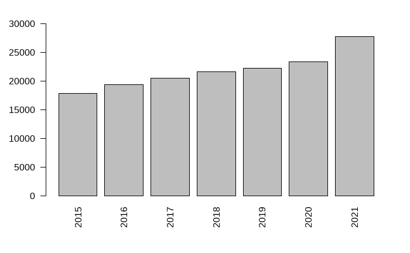

```r
barplot(table(data$year), ylim=c(0,30000), las = 2)
```

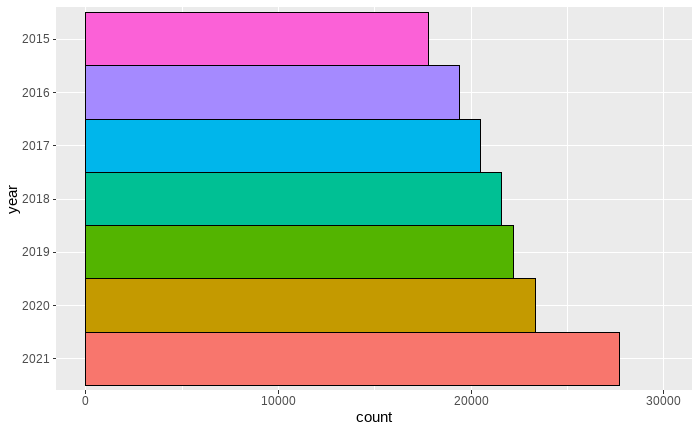

```r
p <- ggplot(data, aes(x = fct_infreq(year), fill = fct_infreq(year))) +
  geom_bar(width = 1, colour = "black", show.legend = FALSE) +
  xlab("year")

p + coord_flip() + scale_y_continuous(limit = c(0, 30000))
```

- exploration of month by plotting

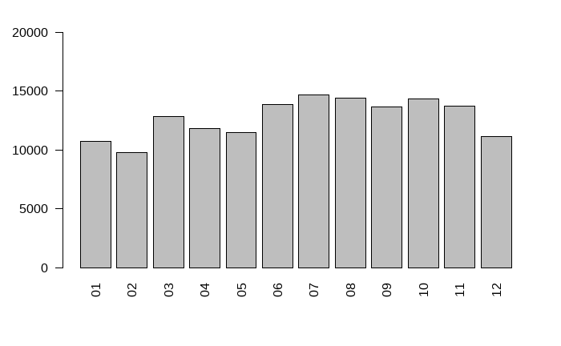

```r
barplot(table(data$month), ylim=c(0,20000), las = 2)
```

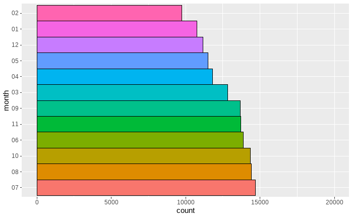

```r
p <- ggplot(data, aes(x = fct_infreq(month), fill = fct_infreq(month))) +
  geom_bar(width = 1, colour = "black", show.legend = FALSE) +
  xlab("month")

p + coord_flip() + scale_y_continuous(limit = c(0, 20000))
```

- uniform distribution type
- the transaction records in every month are about the same, ranges from 9,000 to 15,000
- July has the highest transaction records
- February has the lowest transaction records

### 2. town

```r
head(data$town)
```

```
[1] "ANG MO KIO" "ANG MO KIO" "ANG MO KIO" "ANG MO KIO" "ANG MO KIO" "ANG MO KIO"
```

```r
tail(data$town)
```

```
[1] "YISHUN" "YISHUN" "YISHUN" "YISHUN" "YISHUN" "YISHUN"
```

```r
str(data$town)
```

```
 chr [1:152455] "ANG MO KIO" "ANG MO KIO" "ANG MO KIO" "ANG MO KIO" "ANG MO KIO" "ANG MO KIO" "ANG MO KIO" ...
```

- explore the number of distinct values of town
- convert to factor

```r
data %>% distinct(town)
```

| town |
| --- |
| ANG MO KIO |
| BEDOK |
| BISHAN |
| BUKIT BATOK |
| BUKIT MERAH |
| BUKIT PANJANG |
| BUKIT TIMAH |
| CENTRAL AREA |
| CHOA CHU KANG |
| CLEMENTI |

[output cut: 16 more lines]

```r
data %>% summarise(na = sum(is.na(town)))
```

| na |
| --- |
| 0 |

```r
data$town <- as.factor(data$town)

str(data$town)
```

```
 Factor w/ 26 levels "ANG MO KIO","BEDOK",..: 1 1 1 1 1 1 1 1 1 1 ...
```

```r
sort(summary(data$town))
```

```
    BUKIT TIMAH   MARINE PARADE    CENTRAL AREA          BISHAN       SERANGOON     JURONG EAST        CLEMENTI
            402             942            1373            2956            3067            3327            3570
      SEMBAWANG         GEYLANG      QUEENSTOWN KALLANG/WHAMPOA       PASIR RIS       TOA PAYOH     BUKIT BATOK
           3703            3857            4285            4465            4765            4828            5353
    BUKIT MERAH   BUKIT PANJANG      ANG MO KIO   CHOA CHU KANG         HOUGANG           BEDOK          YISHUN
           5860            5922            6770            6874            7529            8726            9822
        PUNGGOL        TAMPINES       WOODLANDS     JURONG WEST        SENGKANG
           9938           10502           10550           10711           12358
```

- there’s no missing value
- exploration by plotting

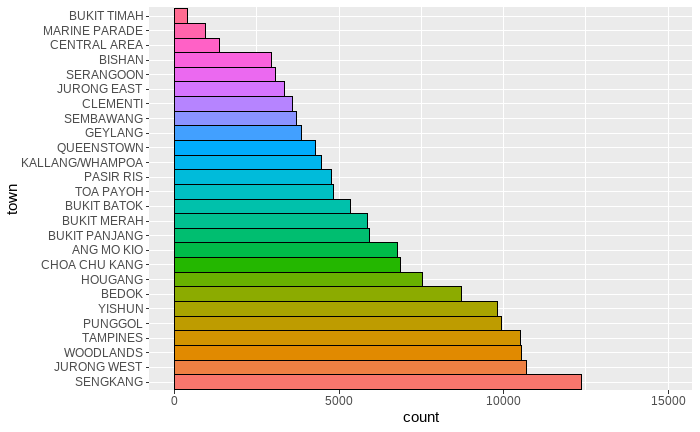

```r
p <- ggplot(data, aes(x = fct_infreq(town), fill = fct_infreq(town))) +
  geom_bar(width = 1, colour = "black", show.legend = FALSE) +
  xlab("town")

p + coord_flip() + scale_y_continuous(limit = c(0, 15000))
```

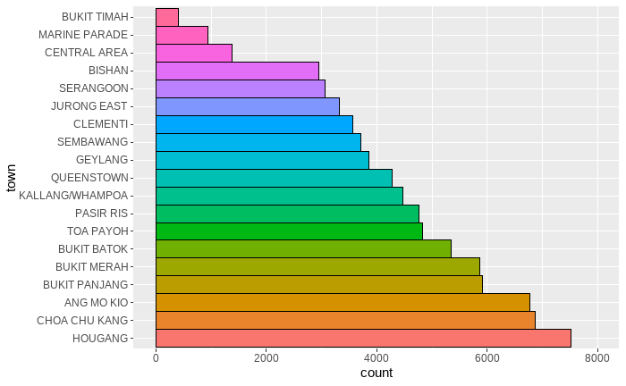

```r
# Zoom in to town with frequency < 10,000
data_filter <- data %>%
  group_by(town) %>%
  filter(n() < 8000)

p <- ggplot(data_filter, aes(x = fct_infreq(town), fill = fct_infreq(town))) +
  geom_bar(width = 1, colour = "black", show.legend = FALSE) +
  xlab("town")

p + coord_flip() + scale_y_continuous(limit = c(0, 8000))
```

- SENGKANG has the highest transaction records, more than 10,000 rows
- BUKIT TIMAH has the lowest transaction records, less than 1,000 rows
- classify towns into region (refer to https://www.mappr.co/counties/regions-of-singapore/)
- classify BUKIT TIMAH as central region (refer to https://en.wikipedia.org/wiki/Bukit_Timah)

```r
data$region <- ifelse (data$town %in% c("BUKIT MERAH","BUKIT TIMAH","GEYLANG","TOA PAYOH",
                                        "BISHAN","KALLANG/WHAMPOA","MARINE PARADE", "CENTRAL AREA", "QUEENSTOWN"), "Central",
                       ifelse (data$town %in% c("TAMPINES","BEDOK","PASIR RIS"), "East",
                               ifelse (data$town %in% c("SEMBAWANG","WOODLANDS","YISHUN"), "North",
                                       ifelse (data$town %in% c("ANG MO KIO","HOUGANG","PUNGGOL","SENGKANG",
                                                                "SERANGOON"), "North-East",
                                               ifelse (data$town %in% c("BUKIT BATOK","BUKIT PANJANG",
                                                                        "CHOA CHU KANG","CLEMENTI",
                                                                        "JURONG EAST","JURONG WEST"), "West",
                                                       as.character(data$town))))))

head(data)
```

|  | town | street_name | block | year | month | flat_type | storey_range | floor_area_sqm | flat_model | lease_commence_date | remaining_lease | resale_price | max_floor_lvl | commercial | market_hawker | miscellaneous | multistorey_carpark | precinct_pavilion | int_year | region |
| --- | --- | --- | --- | --- | --- | --- | --- | --- | --- | --- | --- | --- | --- | --- | --- | --- | --- | --- | --- | --- |
| 1 | ANG MO KIO | ANG MO KIO AVE 1 | 205 | 2019 | 01 | 4 ROOM | 07 TO 09 | 98 | New Generation | 1977 | 684 | 408000 | 11 | 1 | 0 | 0 | 0 | 0 | 2019 | North-East |
| 2 | ANG MO KIO | ANG MO KIO AVE 1 | 205 | 2019 | 07 | 4 ROOM | 10 TO 12 | 98 | New Generation | 1977 | 678 | 405000 | 11 | 1 | 0 | 0 | 0 | 0 | 2019 | North-East |
| 3 | ANG MO KIO | ANG MO KIO AVE 1 | 205 | 2016 | 11 | 4 ROOM | 04 TO 06 | 98 | New Generation | 1977 | 708 | 475000 | 11 | 1 | 0 | 0 | 0 | 0 | 2016 | North-East |
| 4 | ANG MO KIO | ANG MO KIO AVE 1 | 205 | 2021 | 06 | 4 ROOM | 01 TO 03 | 98 | New Generation | 1977 | 656 | 416800 | 11 | 1 | 0 | 0 | 0 | 0 | 2021 | North-East |
| 5 | ANG MO KIO | ANG MO KIO AVE 1 | 207 | 2019 | 09 | 4 ROOM | 04 TO 06 | 97 | New Generation | 1976 | 670 | 360000 | 11 | 0 | 0 | 0 | 0 | 0 | 2019 | North-East |
| 6 | ANG MO KIO | ANG MO KIO AVE 1 | 207 | 2020 | 02 | 4 ROOM | 10 TO 12 | 97 | New Generation | 1976 | 665 | 410000 | 11 | 0 | 0 | 0 | 0 | 0 | 2020 | North-East |

```r
head(data$region)
```

```
[1] "North-East" "North-East" "North-East" "North-East" "North-East" "North-East"
```

```r
tail(data$region)
```

```
[1] "North" "North" "North" "North" "North" "North"
```

```r
str(data$region)
```

```
 chr [1:152455] "North-East" "North-East" "North-East" "North-East" "North-East" "North-East" "North-East" ...
```

```r
data$region <- as.factor(data$region)

str(data$region)
```

```
 Factor w/ 5 levels "Central","East",..: 4 4 4 4 4 4 4 4 4 4 ...
```

```r
sort(summary(data$region))
```

```
      East      North    Central       West North-East
     23993      24075      28968      35757      39662
```

- exploration by plotting

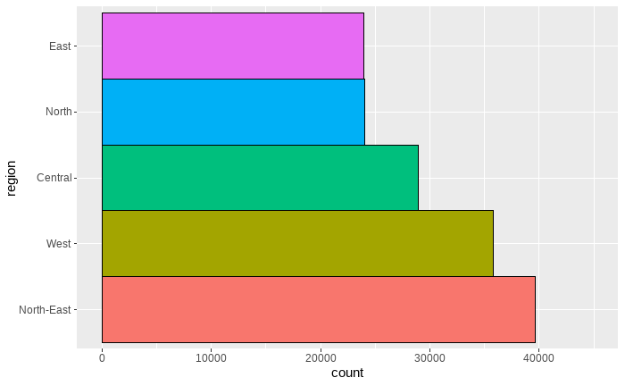

```r
p <- ggplot(data, aes(x = fct_infreq(region), fill = fct_infreq(region))) +
  geom_bar(width = 1, colour = "black", show.legend = FALSE) +
  xlab("region")

p + coord_flip() + scale_y_continuous(limit = c(0, 45000))
```

- North-East has the highest transaction records, nearly 40,000 rows
- East has the lowest transaction records, less than 25,000 rows

### 3. flat_type

```r
head(data$flat_type)
```

```
[1] "4 ROOM" "4 ROOM" "4 ROOM" "4 ROOM" "4 ROOM" "4 ROOM"
```

```r
tail(data$flat_type)
```

```
[1] "5 ROOM" "4 ROOM" "5 ROOM" "5 ROOM" "4 ROOM" "5 ROOM"
```

```r
str(data$flat_type)
```

```
 chr [1:152455] "4 ROOM" "4 ROOM" "4 ROOM" "4 ROOM" "4 ROOM" "4 ROOM" "4 ROOM" "4 ROOM" "4 ROOM" "4 ROOM" "4 ROOM" ...
```

- explore the number of distinct values of flat type

```r
data %>% distinct(flat_type)
```

| flat_type |
| --- |
| 4 ROOM |
| 3 ROOM |
| 5 ROOM |
| EXECUTIVE |
| 2 ROOM |
| MULTI-GENERATION |
| 1 ROOM |

```r
data %>% summarise(na = sum(is.na(flat_type)))
```

| na |
| --- |
| 0 |

- there’s no missing value
- convert to factor

```r
data$flat_type <- as.factor(data$flat_type)

str(data$flat_type)
```

```
 Factor w/ 7 levels "1 ROOM","2 ROOM",..: 4 4 4 4 4 4 4 4 4 4 ...
```

```r
sort(summary(data$flat_type))
```

```
          1 ROOM MULTI-GENERATION           2 ROOM        EXECUTIVE           3 ROOM           5 ROOM           4 ROOM
              62               65             2051            12046            36960            38069            63202
```

- exploration by plotting

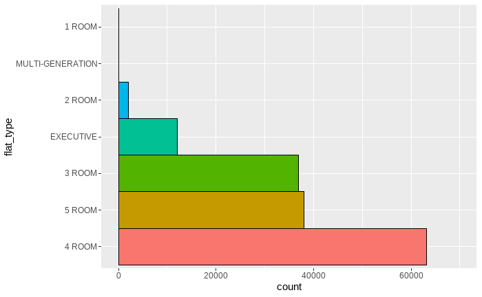

```r
p <- ggplot(data, aes(x = fct_infreq(flat_type), fill = fct_infreq(flat_type))) +
  geom_bar(width = 1, colour = "black", show.legend = FALSE) +
  xlab("flat_type")

p + coord_flip() + scale_y_continuous(limit = c(0, 70000))
```

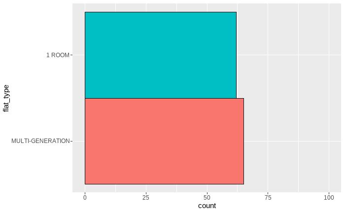

```r
# Zoom in
data_filter <- data %>%
  group_by(flat_type) %>%
  filter(n() < 100)

p <- ggplot(data_filter, aes(x = fct_infreq(flat_type), fill = fct_infreq(flat_type))) +
  geom_bar(width = 1, colour = "black", show.legend = FALSE) +
  xlab("flat_type")

p + coord_flip() + scale_y_continuous(limit = c(0, 100))
```

- 4 ROOM type HDB has the highest transaction records, more than 60,000 rows
- 1 ROOM type HDB has the lowest transaction records, less than 100 rows
- both MULTI-GENERATION and 1 ROOM type HDB have less than 100 transaction records, it is logical as not much HDB in these two types
- reference: https://www.hdb.gov.sg/residential/buying-a-flat/resale/getting-started/types-of-flats
- MULTI-GENERATION:
- Eligible multi-generation families living under one roof in a 3Gen flat can delight in closer family ties. With 2 bedrooms with attached bathrooms, and 2 other bedrooms, it easily supports the needs of larger households.

### 4. block

```r
head(data$block)
```

```
[1] "205" "205" "205" "205" "207" "207"
```

```r
tail(data$block)
```

```
[1] "880" "880" "880" "880" "880" "880"
```

```r
str(data$block)
```

```
 chr [1:152455] "205" "205" "205" "205" "207" "207" "207" "207" "207" "207" "207" "207" "207" "207" "207" "208" "208" ...
```

- explore the number of distinct values of block
- convert to factor

```r
data %>%
  distinct(block) %>%
  head()
```

|  | block |
| --- | --- |
| 1 | 205 |
| 2 | 207 |
| 3 | 208 |
| 4 | 215 |
| 5 | 216 |
| 6 | 218 |

```r
data %>%
  distinct(block) %>%
  tail()
```

|  | block |
| --- | --- |
| 2560 | 511B |
| 2561 | 511C |
| 2562 | 512A |
| 2563 | 512B |
| 2564 | 512C |
| 2565 | 640A |

```r
data %>% summarise(na = sum(is.na(block)))
```

| na |
| --- |
| 0 |

```r
data$block <- as.factor(data$block)

str(data$block)
```

```
 Factor w/ 2565 levels "1","10","100",..: 386 386 386 386 395 395 395 395 395 395 ...
```

```r
sort(summary(data$block))
```

```
    535      27     407      26     205     132     230     140     418     202     134     154     408     231      35
    209     210     211     212     213     214     214     215     215     218     219     219     220     221     221
     53     229      44      16     204      43     148     208     411     417     421     138     232     420      51
    222     223     224     225     226     226     227     227     227     227     230     231     231     231     232
    131     211     416     135     406      57      30     145     118     146     141     142     425      15      10
    233     235     235     237     238     239     241     242     245     247     249     249     249     251     252
    123      55      54     104     129      19      32     126     210     119     128      18     120     117     106
    253     259     260     263     263     264     269     273     274     275     284     288     297     298     308
     50     124     125     122      28      34     116      23      17      21     103     105     130      11       5
    308     313     315     316     316     320     321     323     326     326     336     341     346     352     354
    121      13      12       6     102      20     111     112      22       4     115     107       7     109       3
    355     357     358     361     365     372     376     380     380     389     390     392     394     398     398
    113     110       9     114     108     101       1       8       2 (Other)
    401     403     408     418     421     440     462     498     549  123467
```

- there’s no missing value
- remove the alphabet in block number to reduce the number of unique value

```r
data$block <- gsub("[^0-9.-]", "", data$block)
data$block <- as.factor(data$block)

data %>%
  distinct(block) %>%
  head()
```

|  | block |
| --- | --- |
| 1 | 205 |
| 2 | 207 |
| 3 | 208 |
| 4 | 215 |
| 5 | 216 |
| 6 | 218 |

```r
data %>%
  distinct(block) %>%
  tail()
```

|  | block |
| --- | --- |
| 974 | 397 |
| 975 | 399 |
| 976 | 398 |
| 977 | 783 |
| 978 | 799 |
| 979 | 800 |

```r
str(data$block)
```

```
 Factor w/ 979 levels "1","10","100",..: 119 119 119 119 121 121 121 121 121 121 ...
```

```r
sort(summary(data$block))
```

```
    303     411     686     168      50     123     408     203     313     125     410     406     202     315     301
    304     304     305     307     308     309     310     312     312     315     315     317     319     319     320
     34     336      21     269     274     118     127     430     208     275     104     504     207     416     130
    320     322     326     327     327     335     339     339     342     342     343     344     345     345     346
    204     268     633      11     117     201     305      13     209      23      26     124     212     183     139
    346     349     349     352     353     355     356     357     357     357     358     361     365     368     371
    443      20     120     128      22     288     316      10     213     289     106      17     105       7     306
    371     372     375     379     380     380     380     382     383     384     388     398     401     401     403
    271     311     116       5       6     103     113     111     112     114     115     180     102     302     119
    404     404     407     414     414     415     415     417     418     418     420     421     426     428     429
    122     126       9       4     272     107     210     121     110     108      12     310     109      28     211
    438     447     447     450     454     455     458     459     469     474     483     484     489     490     491
     18     273     101       3     138       8     308       2       1 (Other)
    495     510     525     532     545     571     591     789     986  112824
```

- exploration by plotting
- select blocks of top 10 highest transaction records and top 10 lowest transaction records

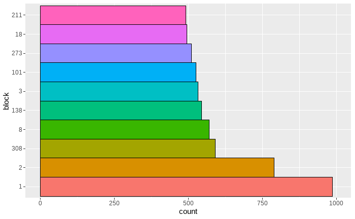

```r
groupby_block <- data  %>%
     group_by(block) %>%
     dplyr::summarise(n = n()) %>%
     arrange(n, decreasing = TRUE)

top10 <- head(groupby_block,10)
btm10 <- tail(groupby_block,10)

# TOP 10 block with highest transactions
data_filter <- data %>%
  filter(block %in% top10$block)

p <- ggplot(data_filter, aes(x = fct_infreq(block), fill = fct_infreq(block))) +
  geom_bar(width = 1, colour = "black", show.legend = FALSE) +
  xlab("block")

p + coord_flip() + scale_y_continuous(limit = c(0, 1000))
```

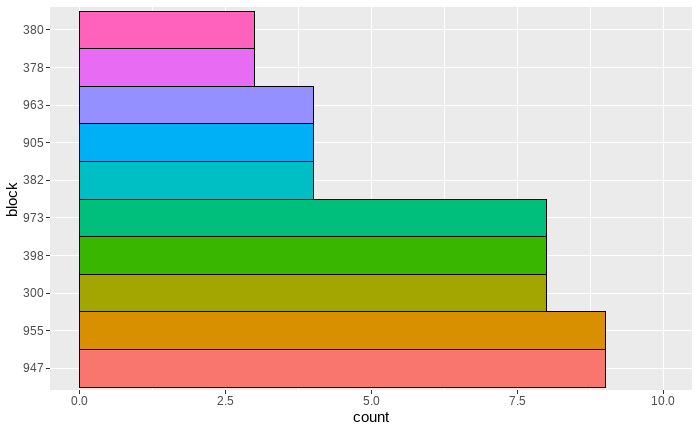

```r
# BOTTOM 10 block with lowest transactions
data_filter <- data %>%
  filter(block %in% btm10$block)

p <- ggplot(data_filter, aes(x = fct_infreq(block), fill = fct_infreq(block))) +
  geom_bar(width = 1, colour = "black", show.legend = FALSE) +
  xlab("block")

p + coord_flip() + scale_y_continuous(limit = c(0, 10))
```

### 5. street_name

```r
head(data$street_name)
```

```
[1] "ANG MO KIO AVE 1" "ANG MO KIO AVE 1" "ANG MO KIO AVE 1" "ANG MO KIO AVE 1" "ANG MO KIO AVE 1" "ANG MO KIO AVE 1"
```

```r
tail(data$street_name)
```

```
[1] "YISHUN ST 81" "YISHUN ST 81" "YISHUN ST 81" "YISHUN ST 81" "YISHUN ST 81" "YISHUN ST 81"
```

```r
str(data$street_name)
```

```
 chr [1:152455] "ANG MO KIO AVE 1" "ANG MO KIO AVE 1" "ANG MO KIO AVE 1" "ANG MO KIO AVE 1" "ANG MO KIO AVE 1" ...
```

- explore the number of distinct values of street_name
- convert to factor

```r
data %>%
  distinct(street_name) %>%
  head()
```

|  | street_name |
| --- | --- |
| 1 | ANG MO KIO AVE 1 |
| 2 | ANG MO KIO AVE 10 |
| 3 | ANG MO KIO AVE 2 |
| 4 | ANG MO KIO AVE 3 |
| 5 | ANG MO KIO AVE 4 |
| 6 | ANG MO KIO AVE 5 |

```r
data %>%
  distinct(street_name) %>%
  tail()
```

|  | street_name |
| --- | --- |
| 551 | YISHUN ST 41 |
| 552 | YISHUN ST 51 |
| 553 | YISHUN ST 61 |
| 554 | YISHUN ST 71 |
| 555 | YISHUN ST 72 |
| 556 | YISHUN ST 81 |

```r
data %>% summarise(na = sum(is.na(street_name)))
```

| na |
| --- |
| 0 |

```r
data$street_name <- as.factor(data$street_name)

str(data$street_name)
```

```
 Factor w/ 556 levels "ADMIRALTY DR",..: 13 13 13 13 13 13 13 13 13 13 ...
```

```r
sort(summary(data$street_name))
```

```
      HOUGANG AVE 5 CHOA CHU KANG AVE 3      TAMPINES ST 83  TELOK BLANGAH CRES         JLN MEMBINA          EUNOS CRES
                445                 453                 456                 462                 463                 464
           FAJAR RD     LOR 2 TOA PAYOH     WOODLANDS AVE 1         CANBERRA RD   JURONG WEST ST 41         PUNGGOL WAY
                466                 468                 470                 472                 473                 483
    TAMPINES CTRL 7     WOODLANDS DR 16     PASIR RIS ST 11        YISHUN AVE 6      HOUGANG AVE 10   JURONG WEST ST 91
                484                 486                 490                 493                 496                 500
    WOODLANDS DR 75   SENGKANG WEST WAY        YISHUN ST 81       HOUGANG AVE 1      TAMPINES ST 71        YISHUN ST 21
                504                 506                 513                 514                 519                 519
      CANTONMENT RD      STRATHMORE AVE        YISHUN ST 61      TAMPINES ST 41           UBI AVE 1      PASIR RIS DR 6
                524                 526                 530                 531                 533                 534
SERANGOON NTH AVE 1      ADMIRALTY LINK   JURONG WEST ST 52 SERANGOON NTH AVE 4        YISHUN ST 11     WOODLANDS ST 13
                535                 538                 551                 551                 552                 556
     TAMPINES ST 22     PASIR RIS ST 21    WOODLANDS CIRCLE      TECK WHYE LANE        BISHAN ST 13      COMPASSVALE ST
                563                 566                 567                 569                 573                 575
 BT PANJANG RING RD       ANCHORVALE RD         BOON LAY DR        BISHAN ST 12      WOODLANDS CRES     WOODLANDS DR 14
                580                 587                 587                 589                 593                 595
   COMPASSVALE LINK CHOA CHU KANG AVE 5     PASIR RIS ST 71    COMPASSVALE LANE       TEBAN GDNS RD   JURONG WEST ST 81
                602                 603                 606                 625                 630                 632
         SIMEI ST 1        SEMBAWANG DR CHOA CHU KANG AVE 4 BT BATOK WEST AVE 6        ADMIRALTY DR     WOODLANDS DR 50
                643                 653                 666                 669                 679                 679
        JELAPANG RD     LOR 1 TOA PAYOH   JURONG WEST ST 42    ANG MO KIO AVE 1   WOODLANDS RING RD      CLEMENTI AVE 4
                689                 695                 698                 702                 706                 709
    PASIR RIS ST 51   JURONG EAST ST 21        MARSILING DR    ANG MO KIO AVE 5          CIRCUIT RD     ANCHORVALE LINK
                727                 729                 730                 769                 776                 778
  JURONG WEST ST 61       FERNVALE LINK        RIVERVALE DR     EDGEDALE PLAINS    ANG MO KIO AVE 4      TAMPINES ST 21
                790                 801                 828                 831                 838                 853
  JURONG WEST ST 64      BEDOK NTH ST 3        PUNGGOL WALK   JURONG WEST ST 65        BEDOK NTH RD      RIVERVALE CRES
                868                 923                 974                 986                1001                1049
           SENJA RD  CHOA CHU KANG CRES       YISHUN AVE 11          PUNGGOL PL       HOUGANG AVE 8            SEGAR RD
               1103                1107                1118                1125                1133                1187
   EDGEFIELD PLAINS        PUNGGOL CTRL         FERNVALE RD    ANG MO KIO AVE 3       PUNGGOL FIELD          PUNGGOL DR
               1193                1368                1403                1521                1550                1567
  ANG MO KIO AVE 10  BEDOK RESERVOIR RD      YISHUN RING RD             (Other)
               1622                1776                2252               79289
```

- there’s no missing value
- exploration by plotting
- select street name of top 10 highest transaction records and top 10 lowest transaction records

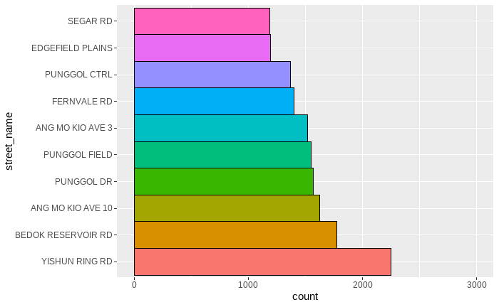

```r
groupby_street <- data  %>%
     group_by(street_name) %>%
     dplyr::summarise(n = n()) %>%
     arrange(n, decreasing = TRUE)

top10 <- head(groupby_street,10)
btm10 <- tail(groupby_street,10)

# TOP 10 street_name with highest transactions
data_filter <- data %>%
  filter(street_name %in% top10$street_name)

p <- ggplot(data_filter, aes(x = fct_infreq(street_name), fill = fct_infreq(street_name))) +
  geom_bar(width = 1, colour = "black", show.legend = FALSE) +
  xlab("street_name")

p + coord_flip() + scale_y_continuous(limit = c(0, 3000))
```

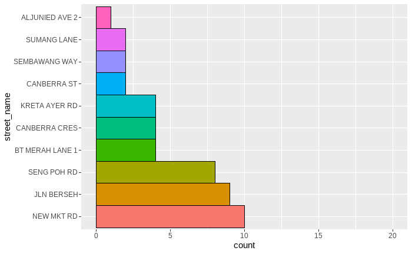

```r
# BOTTOM 10 street_name with lowest transactions
data_filter <- data %>%
  filter(street_name %in% btm10$street_name)

p <- ggplot(data_filter, aes(x = fct_infreq(street_name), fill = fct_infreq(street_name))) +
  geom_bar(width = 1, colour = "black", show.legend = FALSE) +
  xlab("street_name")

p + coord_flip() + scale_y_continuous(limit = c(0, 20))
```

### 6. storey_range

```r
head(data$storey_range)
```

```
[1] "07 TO 09" "10 TO 12" "04 TO 06" "01 TO 03" "04 TO 06" "10 TO 12"
```

```r
tail(data$storey_range)
```

```
[1] "04 TO 06" "01 TO 03" "04 TO 06" "07 TO 09" "04 TO 06" "04 TO 06"
```

```r
str(data$storey_range)
```

```
 chr [1:152455] "07 TO 09" "10 TO 12" "04 TO 06" "01 TO 03" "04 TO 06" "10 TO 12" "04 TO 06" "07 TO 09" "04 TO 06" ...
```

- explore the number of distinct values of storey_range

```r
unique(sort(data$storey_range))
```

```
 [1] "01 TO 03" "04 TO 06" "07 TO 09" "10 TO 12" "13 TO 15" "16 TO 18" "19 TO 21" "22 TO 24" "25 TO 27" "28 TO 30"
[11] "31 TO 33" "34 TO 36" "37 TO 39" "40 TO 42" "43 TO 45" "46 TO 48" "49 TO 51"
```

```r
data %>% summarise(na = sum(is.na(storey_range)))
```

| na |
| --- |
| 0 |

- there’s no missing value
- convert storey_range to factor

```r
data$storey_range <- as.factor(data$storey_range)
sort(summary(data$storey_range))
```

```
49 TO 51 46 TO 48 43 TO 45 40 TO 42 37 TO 39 34 TO 36 31 TO 33 28 TO 30 25 TO 27 22 TO 24 19 TO 21 16 TO 18 13 TO 15
      12       36       39      157      312      325      347      692     1096     1999     2708     6440    14199
01 TO 03 10 TO 12 07 TO 09 04 TO 06
   27587    28529    32320    35657
```

- exploration by plotting

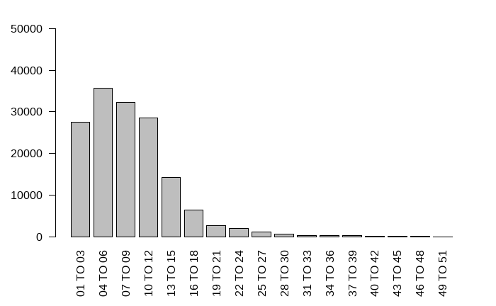

```r
barplot(table(data$storey_range), ylim=c(0,50000), las = 2)
```

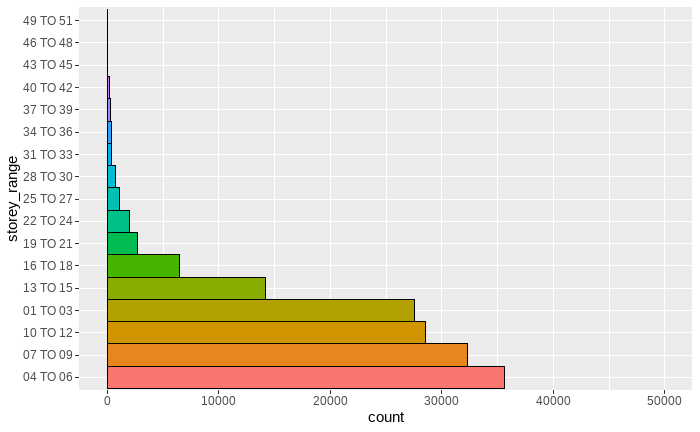

```r
p <- ggplot(data, aes(x = fct_infreq(storey_range), fill = fct_infreq(storey_range))) +
  geom_bar(width = 1, colour = "black", show.legend = FALSE) +
  xlab("storey_range")

p + coord_flip() + scale_y_continuous(limit = c(0, 50000))
```

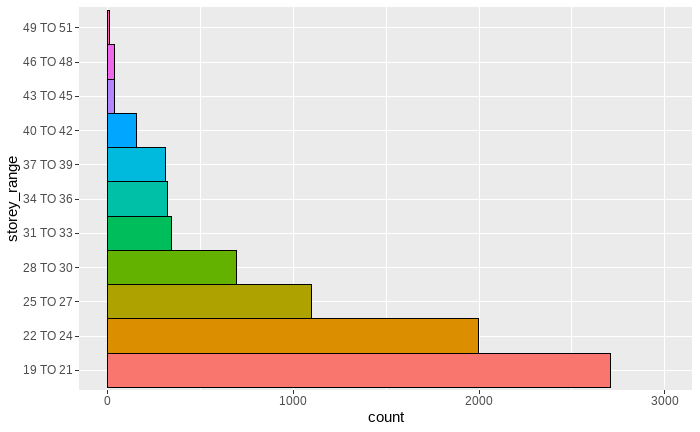

```r
# Zoom in
data_filter <- data %>%
  group_by(storey_range) %>%
  filter(n() < 3000)

p <- ggplot(data_filter, aes(x = fct_infreq(storey_range), fill = fct_infreq(storey_range))) +
  geom_bar(width = 1, colour = "black", show.legend = FALSE) +
  xlab("storey_range")

p + coord_flip() + scale_y_continuous(limit = c(0, 3000))
```

- Storey range of 04 TO 06 has the highest transaction records, more than 35,000 rows
- Storey range of 49 TO 51 has the lowest transaction records, less than 500 rows
- Storey range from 01 TO 12 has higher transaction records compared to other floor level

### 7. floor_area_sqm

```r
head(data$floor_area_sqm)
```

```
[1] 98 98 98 98 97 97
```

```r
tail(data$floor_area_sqm)
```

```
[1] 122 104 127 122 104 122
```

```r
str(data$floor_area_sqm)
```

```
 num [1:152455] 98 98 98 98 97 97 97 97 98 97 ...
```

```r
data %>% summarise(na = sum(is.nan(floor_area_sqm)))
```

| na |
| --- |
| 0 |

```r
summary(data$floor_area_sqm)
```

```
   Min. 1st Qu.  Median    Mean 3rd Qu.    Max.
  31.00   82.00   95.00   97.65  113.00  280.00
```

- there’s no missing value
- exploration by plotting

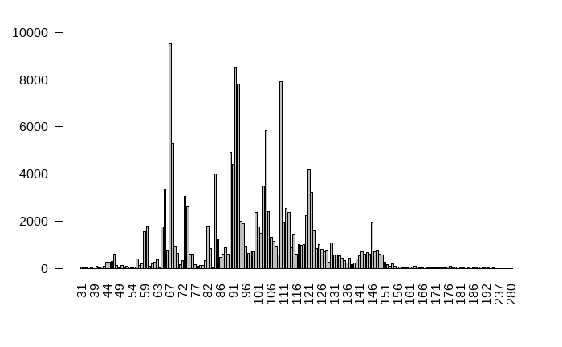

```r
barplot(table(data$floor_area_sqm), ylim=c(0,10000), las = 2)
```

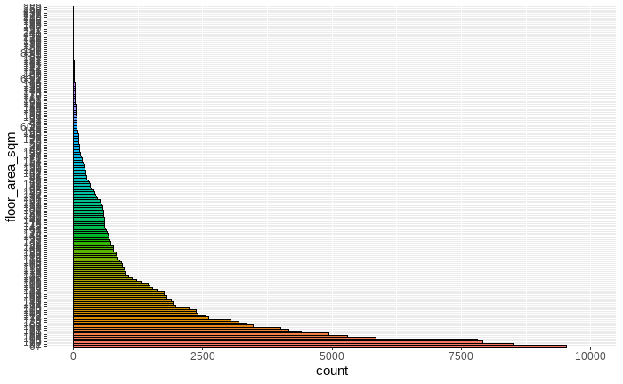

```r
data_plot <- data

data_plot$floor_area_sqm <- as.factor(data_plot$floor_area_sqm)
p <- ggplot(data_plot, aes(x = fct_infreq(floor_area_sqm), fill = fct_infreq(floor_area_sqm))) +
  geom_bar(width = 1, colour = "black", show.legend = FALSE) +
  xlab("floor_area_sqm")

p + coord_flip() + scale_y_continuous(limit = c(0, 10000))
```

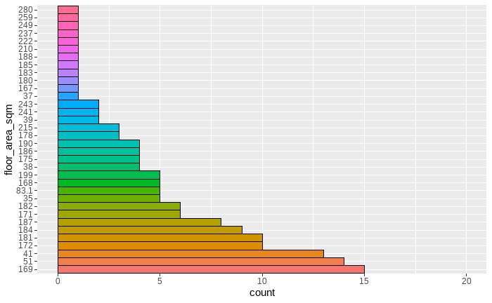

```r
# Zoom in
data_filter <- data_plot %>%
  group_by(floor_area_sqm) %>%
  filter(n() < 20)

p <- ggplot(data_filter, aes(x = fct_infreq(floor_area_sqm), fill = fct_infreq(floor_area_sqm))) +
  geom_bar(width = 1, colour = "black", show.legend = FALSE) +
  xlab("floor_area_sqm")

p + coord_flip() + scale_y_continuous(limit = c(0, 20))
```

- binning

```r
summary(data$floor_area_sqm)
```

```
   Min. 1st Qu.  Median    Mean 3rd Qu.    Max.
  31.00   82.00   95.00   97.65  113.00  280.00
```

```r
max(data$floor_area_sqm) -  min(data$floor_area_sqm)
```

```
[1] 249
```

```r
lower_boundary <- c(seq(30, 270, by=20))
upper_boundary <- c(seq(50, 300, by=20))
lower_boundary
```

```
 [1]  30  50  70  90 110 130 150 170 190 210 230 250 270
```

```r
upper_boundary
```

```
 [1]  50  70  90 110 130 150 170 190 210 230 250 270 290
```

```r
bin_label <- c(paste(paste(lower_boundary, "-"),upper_boundary))
bin_label
```

```
 [1] "30 - 50"   "50 - 70"   "70 - 90"   "90 - 110"  "110 - 130" "130 - 150" "150 - 170" "170 - 190" "190 - 210"
[10] "210 - 230" "230 - 250" "250 - 270" "270 - 290"
```

```r
data$floor_area_sqm_bins <- cut(data$floor_area_sqm, breaks=c(seq(30, 300, by=20)), labels=bin_label)

data %>% select(floor_area_sqm, floor_area_sqm_bins) %>% head()
```

|  | floor_area_sqm | floor_area_sqm_bins |
| --- | --- | --- |
| 1 | 98 | 90 - 110 |
| 2 | 98 | 90 - 110 |
| 3 | 98 | 90 - 110 |
| 4 | 98 | 90 - 110 |
| 5 | 97 | 90 - 110 |
| 6 | 97 | 90 - 110 |

```r
str(data$floor_area_sqm_bins)
```

```
 Factor w/ 13 levels "30 - 50","50 - 70",..: 4 4 4 4 4 4 4 4 4 4 ...
```

```r
summary(data$floor_area_sqm_bins)
```

```
  30 - 50   50 - 70   70 - 90  90 - 110 110 - 130 130 - 150 150 - 170 170 - 190 190 - 210 210 - 230 230 - 250 250 - 270
     2031     27467     23493     56799     29467     11494      1276       369        47         4         6         1
270 - 290
        1
```

```r
data %>% filter(is.na(floor_area_sqm_bins)) %>% select(floor_area_sqm, floor_area_sqm_bins) %>% head()
```

| floor_area_sqm | floor_area_sqm_bins |
| --- | --- |

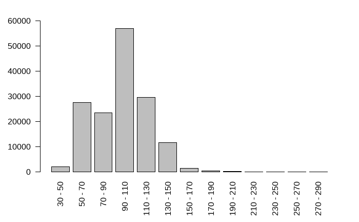

```r
barplot(table(data$floor_area_sqm_bins), ylim=c(0,60000), las = 2)
```

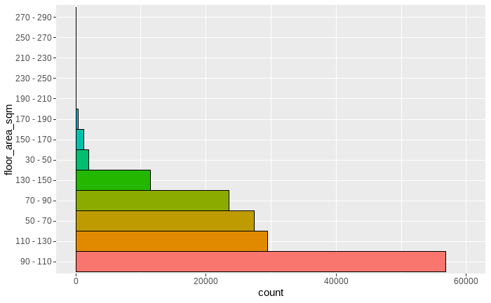

```r
p <- ggplot(data, aes(x = fct_infreq(floor_area_sqm_bins), fill = fct_infreq(floor_area_sqm_bins))) +
  geom_bar(width = 1, colour = "black", show.legend = FALSE) +
  xlab("floor_area_sqm")

p + coord_flip() + scale_y_continuous(limit = c(0, 60000))
```

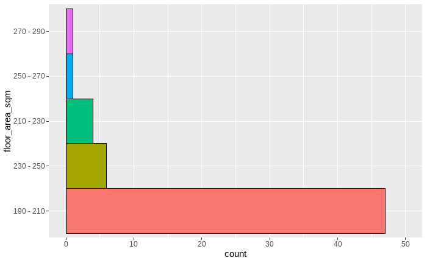

```r
# Zoom in to
data_filter <- data %>%
  group_by(floor_area_sqm_bins) %>%
  filter(n() < 50)

p <- ggplot(data_filter, aes(x = fct_infreq(floor_area_sqm_bins), fill = fct_infreq(floor_area_sqm_bins))) +
  geom_bar(width = 1, colour = "black", show.legend = FALSE) +
  xlab("floor_area_sqm")

p + coord_flip() + scale_y_continuous(limit = c(0, 50))
```

- Floor area (sqm) from 90-110 has the highest transaction records, more than 50,000 rows
- Floor area (sqm) from 250-290 has the lowest transaction records, less than 5 rows
- Most of the HDB has floor area ranges from 50-150 sqm
- Create new column - price per sqm

```r
data$price_per_sqm <- round(data$resale_price / data$floor_area_sqm, 2)
head(data)
```

|  | town | street_name | block | year | month | flat_type | storey_range | floor_area_sqm | flat_model | lease_commence_date | remaining_lease | resale_price | max_floor_lvl | commercial | market_hawker | miscellaneous | multistorey_carpark | precinct_pavilion | int_year | region | floor_area_sqm_bins | price_per_sqm |
| --- | --- | --- | --- | --- | --- | --- | --- | --- | --- | --- | --- | --- | --- | --- | --- | --- | --- | --- | --- | --- | --- | --- |
| 1 | ANG MO KIO | ANG MO KIO AVE 1 | 205 | 2019 | 01 | 4 ROOM | 07 TO 09 | 98 | New Generation | 1977 | 684 | 408000 | 11 | 1 | 0 | 0 | 0 | 0 | 2019 | North-East | 90 - 110 | 4163.27 |
| 2 | ANG MO KIO | ANG MO KIO AVE 1 | 205 | 2019 | 07 | 4 ROOM | 10 TO 12 | 98 | New Generation | 1977 | 678 | 405000 | 11 | 1 | 0 | 0 | 0 | 0 | 2019 | North-East | 90 - 110 | 4132.65 |
| 3 | ANG MO KIO | ANG MO KIO AVE 1 | 205 | 2016 | 11 | 4 ROOM | 04 TO 06 | 98 | New Generation | 1977 | 708 | 475000 | 11 | 1 | 0 | 0 | 0 | 0 | 2016 | North-East | 90 - 110 | 4846.94 |
| 4 | ANG MO KIO | ANG MO KIO AVE 1 | 205 | 2021 | 06 | 4 ROOM | 01 TO 03 | 98 | New Generation | 1977 | 656 | 416800 | 11 | 1 | 0 | 0 | 0 | 0 | 2021 | North-East | 90 - 110 | 4253.06 |
| 5 | ANG MO KIO | ANG MO KIO AVE 1 | 207 | 2019 | 09 | 4 ROOM | 04 TO 06 | 97 | New Generation | 1976 | 670 | 360000 | 11 | 0 | 0 | 0 | 0 | 0 | 2019 | North-East | 90 - 110 | 3711.34 |
| 6 | ANG MO KIO | ANG MO KIO AVE 1 | 207 | 2020 | 02 | 4 ROOM | 10 TO 12 | 97 | New Generation | 1976 | 665 | 410000 | 11 | 0 | 0 | 0 | 0 | 0 | 2020 | North-East | 90 - 110 | 4226.80 |

```r
tail(data)
```

|  | town | street_name | block | year | month | flat_type | storey_range | floor_area_sqm | flat_model | lease_commence_date | remaining_lease | resale_price | max_floor_lvl | commercial | market_hawker | miscellaneous | multistorey_carpark | precinct_pavilion | int_year | region | floor_area_sqm_bins | price_per_sqm |
| --- | --- | --- | --- | --- | --- | --- | --- | --- | --- | --- | --- | --- | --- | --- | --- | --- | --- | --- | --- | --- | --- | --- |
| 152450 | YISHUN | YISHUN ST 81 | 880 | 2015 | 08 | 5 ROOM | 04 TO 06 | 122 | Improved | 1988 | 852 | 480000 | 11 | 0 | 0 | 0 | 0 | 0 | 2015 | North | 110 - 130 | 3934.43 |
| 152451 | YISHUN | YISHUN ST 81 | 880 | 2020 | 09 | 4 ROOM | 01 TO 03 | 104 | Model A | 1988 | 800 | 313000 | 11 | 0 | 0 | 0 | 0 | 0 | 2020 | North | 90 - 110 | 3009.62 |
| 152452 | YISHUN | YISHUN ST 81 | 880 | 2015 | 03 | 5 ROOM | 04 TO 06 | 127 | Improved | 1988 | 864 | 483000 | 11 | 0 | 0 | 0 | 0 | 0 | 2015 | North | 110 - 130 | 3803.15 |
| 152453 | YISHUN | YISHUN ST 81 | 880 | 2016 | 05 | 5 ROOM | 07 TO 09 | 122 | Improved | 1988 | 840 | 475000 | 11 | 0 | 0 | 0 | 0 | 0 | 2016 | North | 110 - 130 | 3893.44 |
| 152454 | YISHUN | YISHUN ST 81 | 880 | 2016 | 05 | 4 ROOM | 04 TO 06 | 104 | Model A | 1988 | 840 | 405000 | 11 | 0 | 0 | 0 | 0 | 0 | 2016 | North | 90 - 110 | 3894.23 |
| 152455 | YISHUN | YISHUN ST 81 | 880 | 2018 | 10 | 5 ROOM | 04 TO 06 | 122 | Improved | 1988 | 823 | 410000 | 11 | 0 | 0 | 0 | 0 | 0 | 2018 | North | 110 - 130 | 3360.66 |

```r
str(data$price_per_sqm)
```

```
 num [1:152455] 4163 4133 4847 4253 3711 ...
```

- exploration by plotting

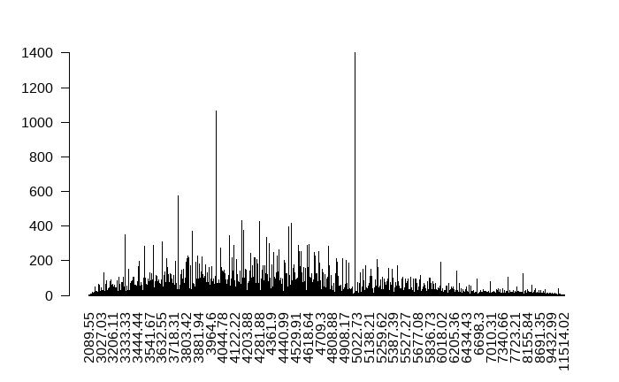

```r
barplot(table(data$price_per_sqm), ylim=c(0,1500), las = 2)
```

### 8. flat_model

```r
head(data$flat_model)
```

```
[1] "New Generation" "New Generation" "New Generation" "New Generation" "New Generation" "New Generation"
```

```r
tail(data$flat_model)
```

```
[1] "Improved" "Model A"  "Improved" "Improved" "Model A"  "Improved"
```

```r
str(data$flat_model)
```

```
 chr [1:152455] "New Generation" "New Generation" "New Generation" "New Generation" "New Generation" "New Generation" ...
```

- explore the number of distinct values of flat_model

```r
unique(sort(data$flat_model))
```

```
 [1] "2-room"                 "Adjoined flat"          "Apartment"              "DBSS"
 [5] "Improved"               "Improved-Maisonette"    "Maisonette"             "Model A"
 [9] "Model A-Maisonette"     "Model A2"               "Multi Generation"       "New Generation"
[13] "Premium Apartment"      "Premium Apartment Loft" "Premium Maisonette"     "Simplified"
[17] "Standard"               "Terrace"                "Type S1"                "Type S2"
```

```r
data %>% summarise(na = sum(is.na(flat_model)))
```

| na |
| --- |
| 0 |

- there’s no missing value
- convert to factor

```r
data$flat_model <- as.factor(data$flat_model)

str(data$flat_model)
```

```
 Factor w/ 20 levels "2-room","Adjoined flat",..: 12 12 12 12 12 12 12 12 12 12 ...
```

```r
sort(summary(data$flat_model))
```

```
    Premium Maisonette                 2-room    Improved-Maisonette       Multi Generation Premium Apartment Loft
                    13                     15                     22                     65                     77
               Terrace                Type S2          Adjoined flat     Model A-Maisonette                Type S1
                    96                    175                    268                    276                    349
              Model A2                   DBSS               Standard             Maisonette              Apartment
                  1945                   2397                   4450                   4516                   6054
            Simplified      Premium Apartment         New Generation               Improved                Model A
                  6402                  16735                  21252                  38329                  49019
```

- exploration by plotting

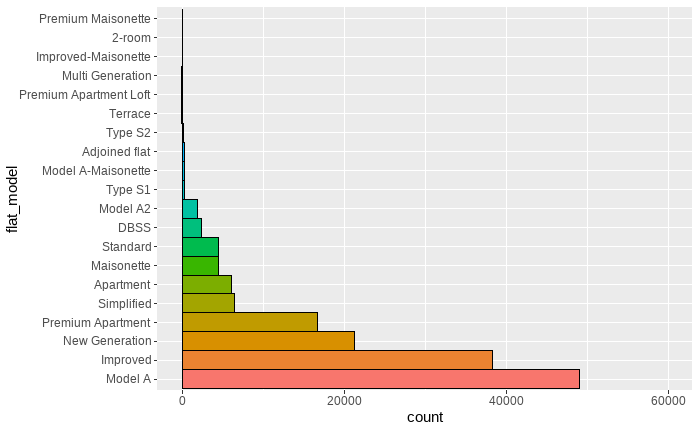

```r
p <- ggplot(data, aes(x = fct_infreq(flat_model), fill = fct_infreq(flat_model))) +
  geom_bar(width = 1, colour = "black", show.legend = FALSE) +
  xlab("flat_model")

p + coord_flip() + scale_y_continuous(limit = c(0, 60000))
```

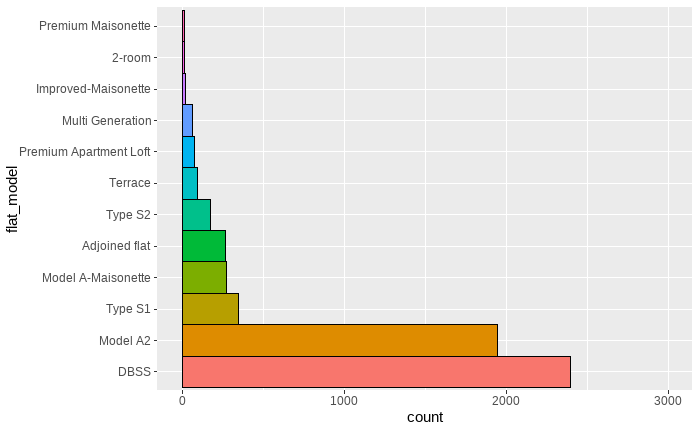

```r
# Zoom in
data_filter <- data %>%
  group_by(flat_model) %>%
  filter(n() < 3000)

p <- ggplot(data_filter, aes(x = fct_infreq(flat_model), fill = fct_infreq(flat_model))) +
  geom_bar(width = 1, colour = "black", show.legend = FALSE) +
  xlab("flat_model")

p + coord_flip() + scale_y_continuous(limit = c(0, 3000))
```

### 9. lease_commence_date

```r
head(data$lease_commence_date)
```

```
[1] 1977 1977 1977 1977 1976 1976
```

```r
tail(data$lease_commence_date)
```

```
[1] 1988 1988 1988 1988 1988 1988
```

```r
str(data$lease_commence_date)
```

```
 int [1:152455] 1977 1977 1977 1977 1976 1976 1976 1976 1976 1976 ...
```

```r
unique(sort(data$lease_commence_date))
```

```
 [1] 1966 1967 1968 1969 1970 1971 1972 1973 1974 1975 1976 1977 1978 1979 1980 1981 1982 1983 1984 1985 1986 1987 1988
[24] 1989 1990 1991 1992 1993 1994 1995 1996 1997 1998 1999 2000 2001 2002 2003 2004 2005 2006 2007 2008 2009 2010 2011
[47] 2012 2013 2014 2015 2016 2017 2018 2019
```

```r
data %>% summarise(na = sum(is.na(lease_commence_date)))
```

| na |
| --- |
| 0 |

```r
summary(data$lease_commence_date)
```

```
   Min. 1st Qu.  Median    Mean 3rd Qu.    Max.
   1966    1984    1993    1994    2003    2019
```

```r
# check whether remaining lease is calculated correctly
data %>%
  filter(!is.na(remaining_lease) && remaining_lease != (99 - (data$int_year - data$lease_commence_date))) %>%
  select(remaining_lease)
```

| remaining_lease |
| --- |
| 684 |
| 678 |
| 708 |
| 656 |
| 670 |
| 665 |
| 681 |
| 654 |
| 667 |
| 702 |

[output cut: 990 more lines]

- there’s no missing value

### 10. resale_price

```r
head(data$resale_price)
```

```
[1] 408000 405000 475000 416800 360000 410000
```

```r
tail(data$resale_price)
```

```
[1] 480000 313000 483000 475000 405000 410000
```

```r
str(data$resale_price)
```

```
 num [1:152455] 408000 405000 475000 416800 360000 ...
```

```r
data %>% summarise(na = sum(is.na(resale_price)))
```

| na |
| --- |
| 0 |

```r
summary(data$resale_price)
```

```
   Min. 1st Qu.  Median    Mean 3rd Qu.    Max.
 140000  343000  420888  453455  530000 1360000
```

- there’s no missing value
- exploration by plotting

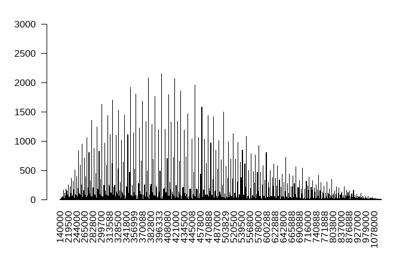

```r
barplot(table(data$resale_price), ylim=c(0,3000), las = 2)
```

- binning

```r
summary(data$resale_price)
```

```
   Min. 1st Qu.  Median    Mean 3rd Qu.    Max.
 140000  343000  420888  453455  530000 1360000
```

```r
max(data$resale_price) -  min(data$resale_price)
```

```
[1] 1220000
```

```r
lower_boundary <- c(seq(79000, 1360000, by=61000))
upper_boundary <- c(seq(140000, 1421000, by=61000))
lower_boundary
```

```
 [1]   79000  140000  201000  262000  323000  384000  445000  506000  567000  628000  689000  750000  811000  872000
[15]  933000  994000 1055000 1116000 1177000 1238000 1299000 1360000
```

```r
upper_boundary
```

```
 [1]  140000  201000  262000  323000  384000  445000  506000  567000  628000  689000  750000  811000  872000  933000
[15]  994000 1055000 1116000 1177000 1238000 1299000 1360000 1421000
```

```r
bin_label <- c(paste(paste(lower_boundary, "-"),upper_boundary))
bin_label
```

```
 [1] "79000 - 140000"    "140000 - 201000"   "201000 - 262000"   "262000 - 323000"   "323000 - 384000"
 [6] "384000 - 445000"   "445000 - 506000"   "506000 - 567000"   "567000 - 628000"   "628000 - 689000"
[11] "689000 - 750000"   "750000 - 811000"   "811000 - 872000"   "872000 - 933000"   "933000 - 994000"
[16] "994000 - 1055000"  "1055000 - 1116000" "1116000 - 1177000" "1177000 - 1238000" "1238000 - 1299000"
[21] "1299000 - 1360000" "1360000 - 1421000"
```

```r
data$resale_price_bins <- cut(data$resale_price, breaks=c(seq(79000, 1421000, by=61000)), labels=bin_label)

data %>% select(resale_price, resale_price_bins) %>% head()
```

|  | resale_price | resale_price_bins |
| --- | --- | --- |
| 1 | 408000 | 384000 - 445000 |
| 2 | 405000 | 384000 - 445000 |
| 3 | 475000 | 445000 - 506000 |
| 4 | 416800 | 384000 - 445000 |
| 5 | 360000 | 323000 - 384000 |
| 6 | 410000 | 384000 - 445000 |

```r
str(data$resale_price_bins)
```

```
 Factor w/ 22 levels "79000 - 140000",..: 6 6 7 6 5 6 6 6 5 7 ...
```

```r
summary(data$resale_price_bins)
```

```
   79000 - 140000   140000 - 201000   201000 - 262000   262000 - 323000   323000 - 384000   384000 - 445000
                2               466              7415             22094             27227             30168
  445000 - 506000   506000 - 567000   567000 - 628000   628000 - 689000   689000 - 750000   750000 - 811000
            21038             13851              9578              7032              5339              3213
  811000 - 872000   872000 - 933000   933000 - 994000  994000 - 1055000 1055000 - 1116000 1116000 - 1177000
             2398              1317               757               313               123                71
1177000 - 1238000 1238000 - 1299000 1299000 - 1360000 1360000 - 1421000
               37                15                 1                 0
```

```r
data %>% filter(is.na(resale_price_bins)) %>% select(resale_price, resale_price_bins) %>% head()
```

| resale_price | resale_price_bins |
| --- | --- |

```r
NA
```

- exploration by plotting

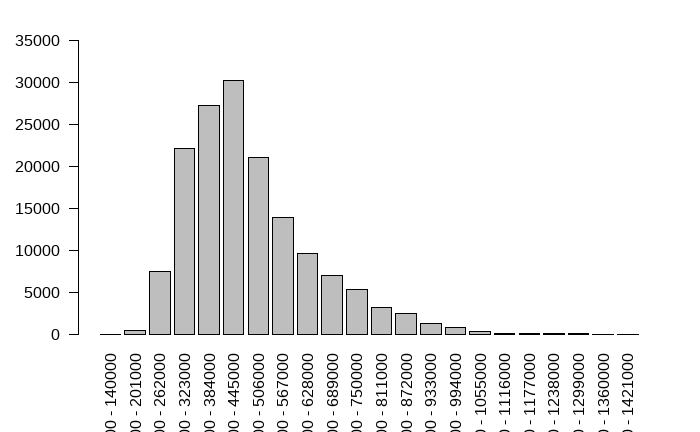

```r
barplot(table(data$resale_price_bins), ylim=c(0,35000), las = 2)
```

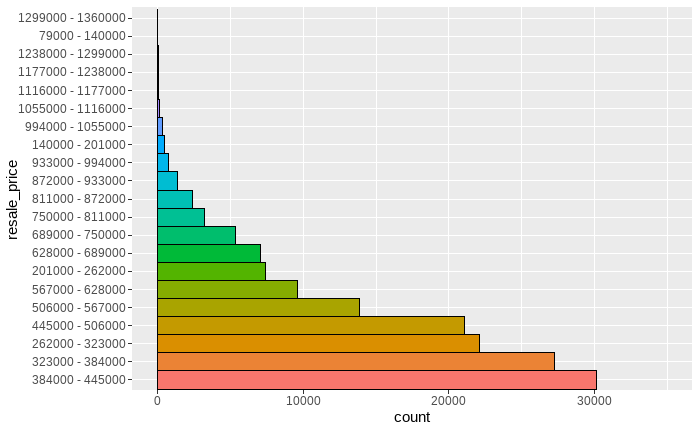

```r
p <- ggplot(data, aes(x = fct_infreq(resale_price_bins), fill = fct_infreq(resale_price_bins))) +
  geom_bar(width = 1, colour = "black", show.legend = FALSE) +
  xlab("resale_price")

p + coord_flip() + scale_y_continuous(limit = c(0, 35000))
```

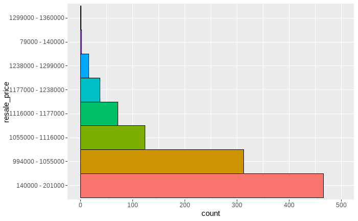

```r
# Zoom in
data_filter <- data %>%
  group_by(resale_price_bins) %>%
  filter(n() < 500)

p <- ggplot(data_filter, aes(x = fct_infreq(resale_price_bins), fill = fct_infreq(resale_price_bins))) +
  geom_bar(width = 1, colour = "black", show.legend = FALSE) +
  xlab("resale_price")

p + coord_flip() + scale_y_continuous(limit = c(0, 500))
```

- Resale price ranges from 384000-445000 has the highest transaction records, more than 30,000 rows
- Resale price ranges from 1299000-1360000 has the lowest transaction records, less than 50 rows
- Most of the HDB resale with price ranges from 262000-567000

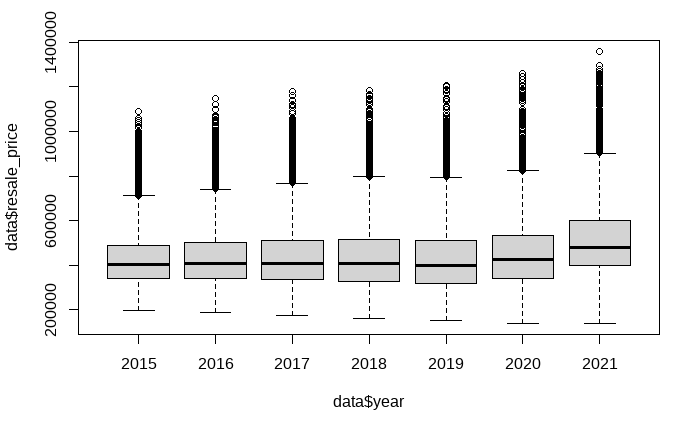

```r
boxplot(data$resale_price ~ data$year)
```

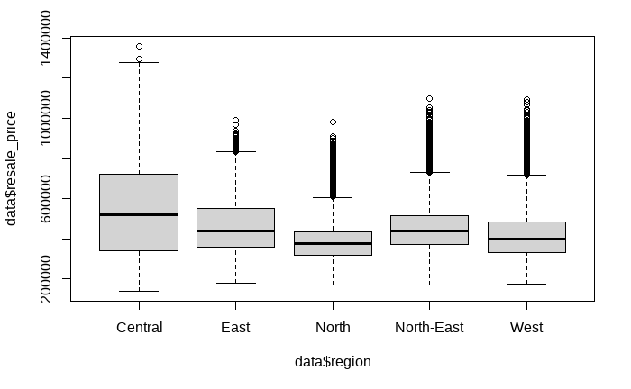

```r
boxplot(data$resale_price ~ data$region)
```

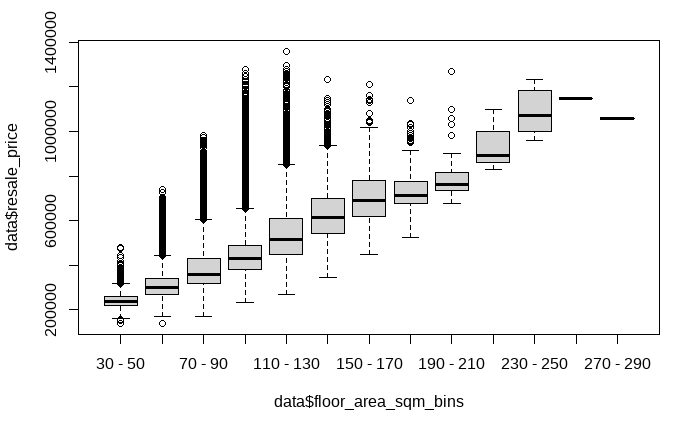

```r
boxplot(data$resale_price ~ data$floor_area_sqm_bins)
```

- correlation between variables

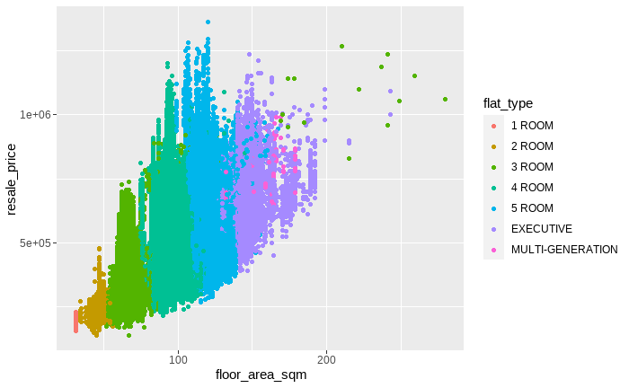

```r
ggplot(data) +
  aes(x = floor_area_sqm, y = resale_price, colour = flat_type) +
  geom_point() +
  scale_color_hue()
```

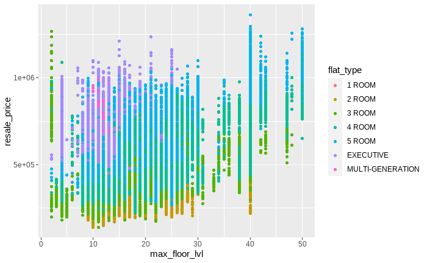

```r
ggplot(data) +
  aes(x = max_floor_lvl, y = resale_price, colour = flat_type) +
  geom_point() +
  scale_color_hue()
```

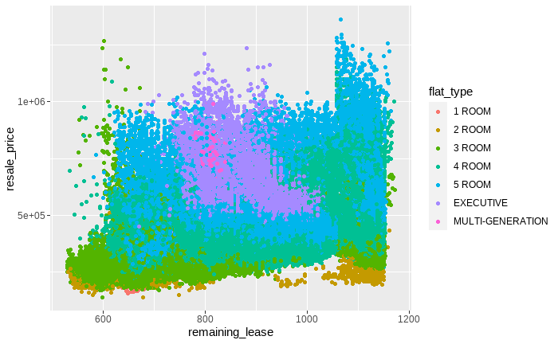

```r
ggplot(data) +
  aes(x = remaining_lease, y = resale_price, colour = flat_type) +
  geom_point() +
  scale_color_hue()
```

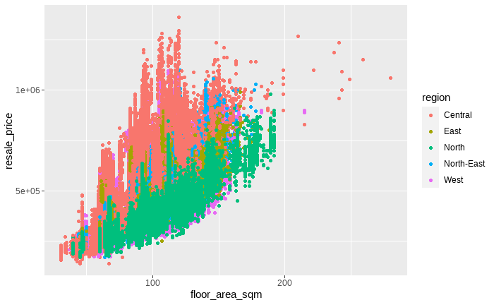

```r
ggplot(data) +
  aes(x = floor_area_sqm, y = resale_price, colour = region) +
  geom_point() +
  scale_color_hue()
```

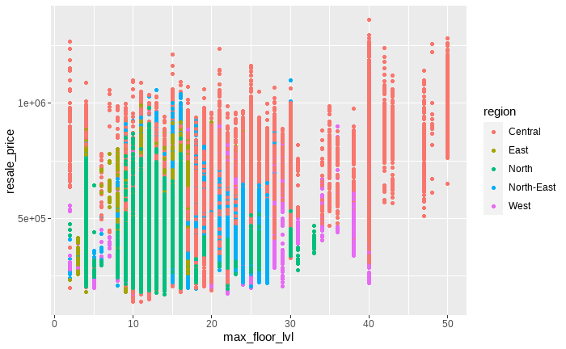

```r
ggplot(data) +
  aes(x = max_floor_lvl, y = resale_price, colour = region) +
  geom_point() +
  scale_color_hue()
```

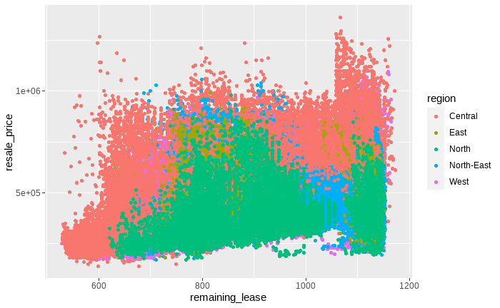

```r
ggplot(data) +
  aes(x = remaining_lease, y = resale_price, colour = region) +
  geom_point() +
  scale_color_hue()
```

### 11. remaining_lease

```r
head(data$remaining_lease)
```

```
[1] 684 678 708 656 670 665
```

```r
tail(data$remaining_lease)
```

```
[1] 852 800 864 840 840 823
```

```r
str(data$remaining_lease)
```

```
 num [1:152455] 684 678 708 656 670 665 681 654 667 702 ...
```

```r
data %>% summarise(na = sum(is.na(remaining_lease)))
```

| na |
| --- |
| 0 |

```r
summary(data$remaining_lease)
```

```
   Min. 1st Qu.  Median    Mean 3rd Qu.    Max.
  529.0   776.0   894.0   895.9  1008.0  1173.0
```

- exploration by plotting

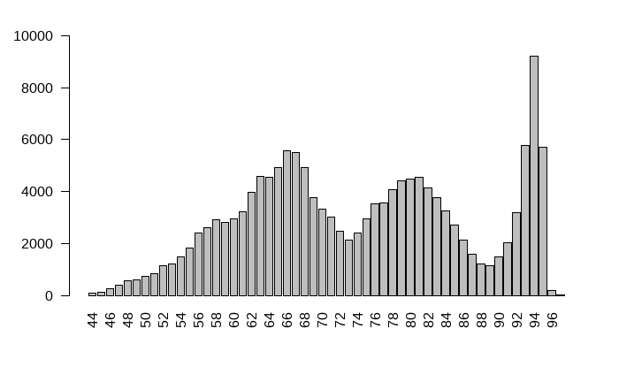

```r
data_plot <- data
data_plot$remaining_lease <- as.integer(data$remaining_lease / 12)

barplot(table(data_plot$remaining_lease), ylim=c(0,10000), las = 2)
```

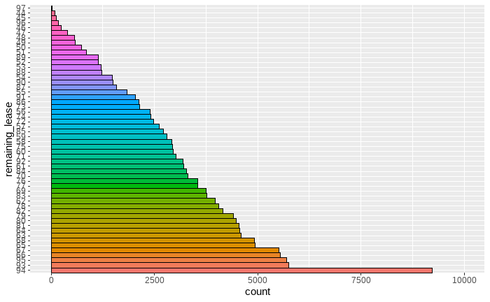

```r
data_plot$remaining_lease <- as.factor(data_plot$remaining_lease)
p <- ggplot(data_plot, aes(x = fct_infreq(remaining_lease), fill = fct_infreq(remaining_lease))) +
  geom_bar(width = 1, colour = "black", show.legend = FALSE) +
  xlab("remaining_lease")

p + coord_flip() + scale_y_continuous(limit = c(0, 10000))
```

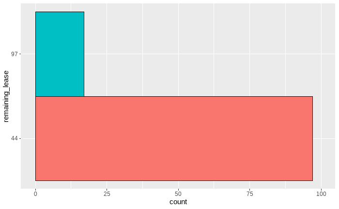

```r
# Zoom in
data_filter <- data_plot %>%
  group_by(remaining_lease) %>%
  filter(n() < 100)

p <- ggplot(data_filter, aes(x = fct_infreq(remaining_lease), fill = fct_infreq(remaining_lease))) +
  geom_bar(width = 1, colour = "black", show.legend = FALSE) +
  xlab("remaining_lease")

p + coord_flip() + scale_y_continuous(limit = c(0, 100))
```

- 94 remaining lease year has the highest transaction records, more than 8,000 rows
- 97 remaining lease year has the lowest transaction records, less than 20 rows
- remaining lease year > 96 has very low transaction records, should be due to the restriction to sell the HDB if purchased less than N years

### 12. max_floor_lvl

```r
head(data$max_floor_lvl)
```

```
[1] 11 11 11 11 11 11
```

```r
tail(data$max_floor_lvl)
```

```
[1] 11 11 11 11 11 11
```

```r
str(data$max_floor_lvl)
```

```
 int [1:152455] 11 11 11 11 11 11 11 11 11 11 ...
```

```r
data %>% summarise(na = sum(is.na(max_floor_lvl)))
```

| na |
| --- |
| 0 |

```r
summary(data$max_floor_lvl)
```

```
   Min. 1st Qu.  Median    Mean 3rd Qu.    Max.
   2.00   12.00   14.00   15.63   17.00   50.00
```

- there’s no missing value
- exploration by plotting

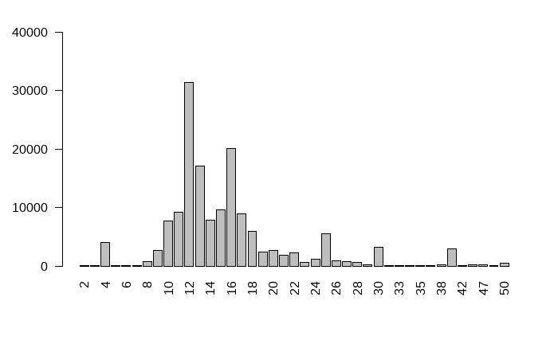

```r
barplot(table(data$max_floor_lvl), ylim=c(0,40000), las = 2)
```

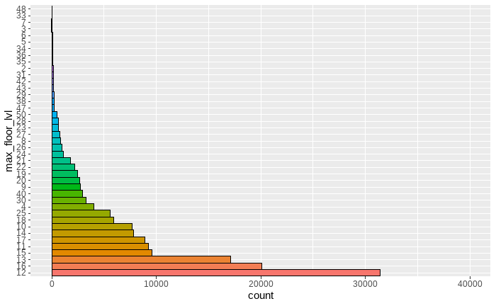

```r
data_plot <- data
data_plot$max_floor_lvl <- as.factor(data_plot$max_floor_lvl)
p <- ggplot(data_plot, aes(x = fct_infreq(max_floor_lvl), fill = fct_infreq(max_floor_lvl))) +
  geom_bar(width = 1, colour = "black", show.legend = FALSE) +
  xlab("max_floor_lvl")

p + coord_flip() + scale_y_continuous(limit = c(0, 40000))
```

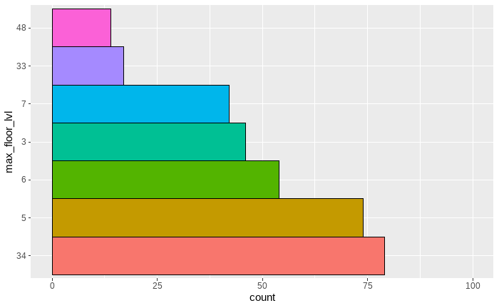

```r
# Zoom in
data_filter <- data_plot %>%
  group_by(max_floor_lvl) %>%
  filter(n() < 100)

p <- ggplot(data_filter, aes(x = fct_infreq(max_floor_lvl), fill = fct_infreq(max_floor_lvl))) +
  geom_bar(width = 1, colour = "black", show.legend = FALSE) +
  xlab("max_floor_lvl")

p + coord_flip() + scale_y_continuous(limit = c(0, 100))
```

- 12 max floor level has the highest transaction records, more than 30,000 rows
- 48 max floor level has the lowest transaction records, less than 20 rows
- Most of the HDB are having 10-18 max floor levels

### 13. commercial

```r
head(data$commercial)
```

```
[1] 1 1 1 1 0 0
```

```r
tail(data$commercial)
```

```
[1] 0 0 0 0 0 0
```

```r
str(data$commercial)
```

```
 num [1:152455] 1 1 1 1 0 0 0 0 0 0 ...
```

```r
unique(data$market_hawker)
```

```
[1] 0 1
```

```r
data %>% summarise(na = sum(is.na(commercial)))
```

| na |
| --- |
| 0 |

```r
NA
```

- there’s no missing value
- exploration by plotting

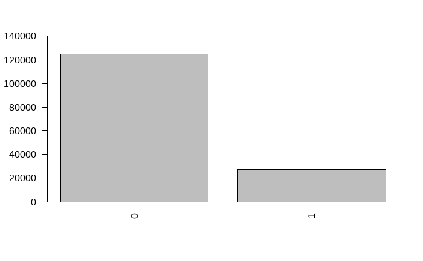

```r
barplot(table(data$commercial), ylim=c(0,150000), las = 2)
```

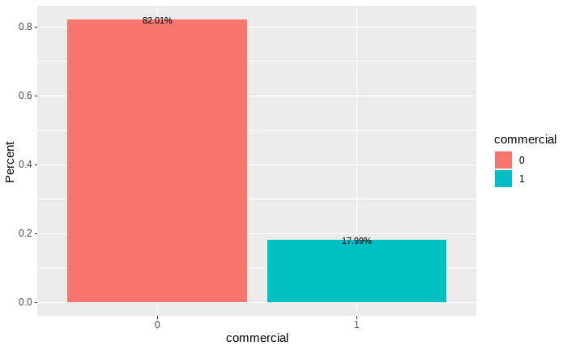

```r
ggplot(data = data, aes(x = factor(commercial), fill = factor(commercial))) +
geom_bar(aes(y = (..count..)/sum(..count..)),
         position = "dodge") +
geom_text(aes(y = (..count..)/sum(..count..),
              label = paste0(round(prop.table(..count..) * 100,2), '%')),
          stat = 'count',
          position = position_dodge(.9),
          size = 3)+
labs(x = 'commercial', y = 'Percent', fill = 'commercial')
```

- Most of the HDB are far away from commercial area

### 14. market_hawker

```r
head(data$market_hawker)
```

```
[1] 0 0 0 0 0 0
```

```r
tail(data$market_hawker)
```

```
[1] 0 0 0 0 0 0
```

```r
str(data$market_hawker)
```

```
 num [1:152455] 0 0 0 0 0 0 0 0 0 0 ...
```

```r
unique(data$market_hawker)
```

```
[1] 0 1
```

```r
data %>% summarise(na = sum(is.na(market_hawker)))
```

| na |
| --- |
| 0 |

```r
NA
```

- there’s no missing value
- exploration by plotting

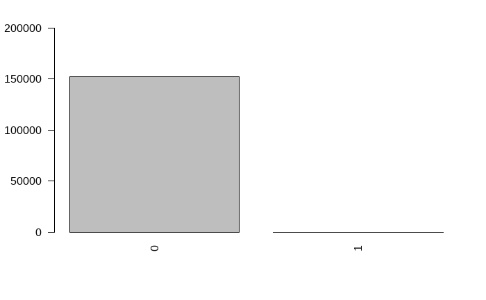

```r
barplot(table(data$market_hawker), ylim=c(0,200000), las = 2)
```

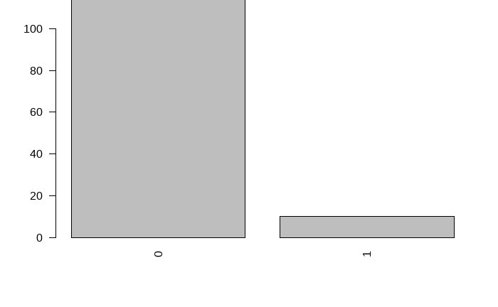

```r
barplot(table(data$market_hawker), ylim=c(0,100), las = 2)
```

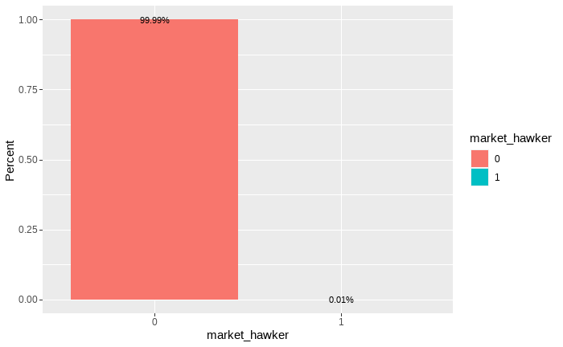

```r
ggplot(data = data, aes(x = factor(market_hawker), fill = factor(market_hawker))) +
geom_bar(aes(y = (..count..)/sum(..count..)),
         position = "dodge") +
geom_text(aes(y = (..count..)/sum(..count..),
              label = paste0(round(prop.table(..count..) * 100,2), '%')),
          stat = 'count',
          position = position_dodge(.9),
          size = 3)+
labs(x = 'market_hawker', y = 'Percent', fill = 'market_hawker')
```

- Most of the HDB are far away from market and hawker area

### 15. miscellaneous

```r
head(data$miscellaneous)
```

```
[1] 0 0 0 0 0 0
```

```r
tail(data$miscellaneous)
```

```
[1] 0 0 0 0 0 0
```

```r
str(data$miscellaneous)
```

```
 num [1:152455] 0 0 0 0 0 0 0 0 0 0 ...
```

```r
unique(data$miscellaneous)
```

```
[1] 0 1
```

```r
data %>% summarise(na = sum(is.na(miscellaneous)))
```

| na |
| --- |
| 0 |

```r
NA
```

- there’s no missing value
- exploration by plotting

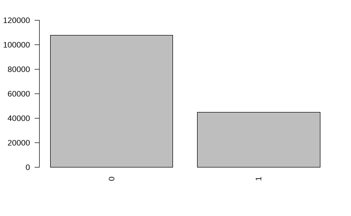

```r
barplot(table(data$miscellaneous), ylim=c(0,120000), las = 2)
```

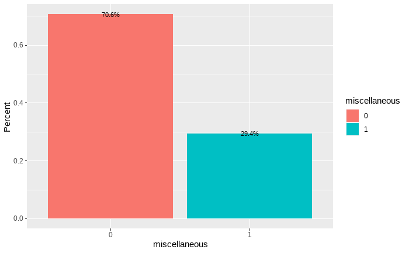

```r
ggplot(data = data, aes(x = factor(miscellaneous), fill = factor(miscellaneous))) +
geom_bar(aes(y = (..count..)/sum(..count..)),
         position = "dodge") +
geom_text(aes(y = (..count..)/sum(..count..),
              label = paste0(round(prop.table(..count..) * 100,2), '%')),
          stat = 'count',
          position = position_dodge(.9),
          size = 3)+
labs(x = 'miscellaneous', y = 'Percent', fill = 'miscellaneous')
```

- Most of the HDB are far away from admin office, childcare centre, education centre, Residents’ Committees centre, etc

### 16. multistorey_carpark

```r
head(data$multistorey_carpark)
```

```
[1] 0 0 0 0 0 0
```

```r
tail(data$multistorey_carpark)
```

```
[1] 0 0 0 0 0 0
```

```r
str(data$multistorey_carpark)
```

```
 num [1:152455] 0 0 0 0 0 0 0 0 0 0 ...
```

```r
unique(data$multistorey_carpark)
```

```
[1] 0 1
```

```r
data %>% summarise(na = sum(is.na(multistorey_carpark)))
```

| na |
| --- |
| 0 |

```r
NA
```

- there’s no missing value
- exploration by plotting

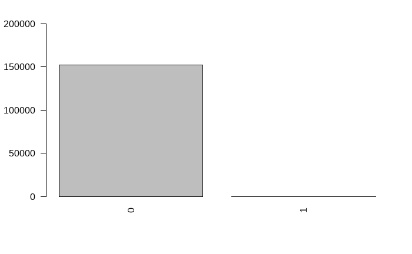

```r
barplot(table(data$multistorey_carpark), ylim=c(0,200000), las = 2)
```

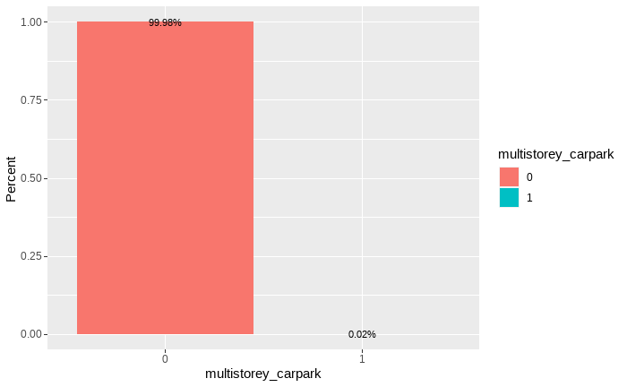

```r
ggplot(data = data, aes(x = factor(multistorey_carpark), fill = factor(multistorey_carpark))) +
geom_bar(aes(y = (..count..)/sum(..count..)),
         position = "dodge") +
geom_text(aes(y = (..count..)/sum(..count..),
              label = paste0(round(prop.table(..count..) * 100,2), '%')),
          stat = 'count',
          position = position_dodge(.9),
          size = 3)+
labs(x = 'multistorey_carpark', y = 'Percent', fill = 'multistorey_carpark')
```

- Most of the HDB do not have multistorey car park

### 17. precinct_pavilion

```r
head(data$precinct_pavilion)
```

```
[1] 0 0 0 0 0 0
```

```r
tail(data$precinct_pavilion)
```

```
[1] 0 0 0 0 0 0
```

```r
str(data$precinct_pavilion)
```

```
 num [1:152455] 0 0 0 0 0 0 0 0 0 0 ...
```

```r
unique(data$precinct_pavilion)
```

```
[1] 0 1
```

```r
data %>% summarise(na = sum(is.na(precinct_pavilion)))
```

| na |
| --- |
| 0 |

```r
NA
```

- there’s no missing value
- exploration by plotting

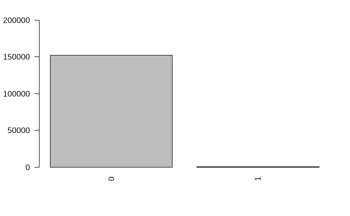

```r
barplot(table(data$precinct_pavilion), ylim=c(0,200000), las = 2)
```

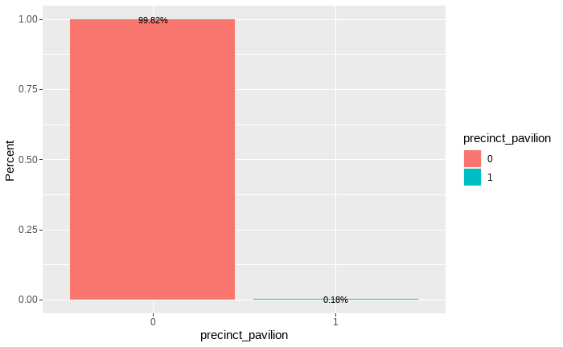

```r
ggplot(data = data, aes(x = factor(precinct_pavilion), fill = factor(precinct_pavilion))) +
geom_bar(aes(y = (..count..)/sum(..count..)),
         position = "dodge") +
geom_text(aes(y = (..count..)/sum(..count..),
              label = paste0(round(prop.table(..count..) * 100,2), '%')),
          stat = 'count',
          position = position_dodge(.9),
          size = 3)+
labs(x = 'precinct_pavilion', y = 'Percent', fill = 'precinct_pavilion')
```

- Most of the HDB do not have precinct pavilion

### Drop Columns

```r
str(data)
```

```
'data.frame':   152455 obs. of  23 variables:
 $ town               : Factor w/ 26 levels "ANG MO KIO","BEDOK",..: 1 1 1 1 1 1 1 1 1 1 ...
 $ street_name        : Factor w/ 556 levels "ADMIRALTY DR",..: 13 13 13 13 13 13 13 13 13 13 ...
 $ block              : Factor w/ 979 levels "1","10","100",..: 119 119 119 119 121 121 121 121 121 121 ...
 $ year               : Factor w/ 7 levels "2015","2016",..: 5 5 2 7 5 6 4 7 6 3 ...
 $ month              : Factor w/ 12 levels "01","02","03",..: 1 7 11 6 9 2 10 2 1 1 ...
 $ flat_type          : Factor w/ 7 levels "1 ROOM","2 ROOM",..: 4 4 4 4 4 4 4 4 4 4 ...
 $ storey_range       : Factor w/ 17 levels "01 TO 03","04 TO 06",..: 3 4 2 1 2 4 2 3 2 2 ...
 $ floor_area_sqm     : num  98 98 98 98 97 97 97 97 98 97 ...
 $ flat_model         : Factor w/ 20 levels "2-room","Adjoined flat",..: 12 12 12 12 12 12 12 12 12 12 ...
 $ lease_commence_date: int  1977 1977 1977 1977 1976 1976 1976 1976 1976 1976 ...
 $ remaining_lease    : num  684 678 708 656 670 665 681 654 667 702 ...
 $ resale_price       : num  408000 405000 475000 416800 360000 ...
 $ max_floor_lvl      : int  11 11 11 11 11 11 11 11 11 11 ...
 $ commercial         : num  1 1 1 1 0 0 0 0 0 0 ...
 $ market_hawker      : num  0 0 0 0 0 0 0 0 0 0 ...
 $ miscellaneous      : num  0 0 0 0 0 0 0 0 0 0 ...
 $ multistorey_carpark: num  0 0 0 0 0 0 0 0 0 0 ...
 $ precinct_pavilion  : num  0 0 0 0 0 0 0 0 0 0 ...
 $ int_year           : int  2019 2019 2016 2021 2019 2020 2018 2021 2020 2017 ...
 $ region             : Factor w/ 5 levels "Central","East",..: 4 4 4 4 4 4 4 4 4 4 ...
 $ floor_area_sqm_bins: Factor w/ 13 levels "30 - 50","50 - 70",..: 4 4 4 4 4 4 4 4 4 4 ...
 $ price_per_sqm      : num  4163 4133 4847 4253 3711 ...
 $ resale_price_bins  : Factor w/ 22 levels "79000 - 140000",..: 6 6 7 6 5 6 6 6 5 7 ...
```

- drop columns that are useless for prediction

```r
data <- data[,-which(names(data) %in% c("lease_commence_date","int_year","floor_area_sqm_bins","resale_price_bins"))]
```

### Explore Cleaned Dataset

```r
summary(data)
```

```
          town                   street_name         block          year           month                  flat_type
 SENGKANG   :12358   YISHUN RING RD    :  2252   1      :   986   2015:17780   07     :14672   1 ROOM          :   62
 JURONG WEST:10711   BEDOK RESERVOIR RD:  1776   2      :   789   2016:19373   08     :14426   2 ROOM          : 2051
 WOODLANDS  :10550   ANG MO KIO AVE 10 :  1622   308    :   591   2017:20509   10     :14339   3 ROOM          :36960
 TAMPINES   :10502   PUNGGOL DR        :  1567   8      :   571   2018:21561   06     :13879   4 ROOM          :63202
 PUNGGOL    : 9938   PUNGGOL FIELD     :  1550   138    :   545   2019:22186   11     :13710   5 ROOM          :38069
 YISHUN     : 9822   ANG MO KIO AVE 3  :  1521   3      :   532   2020:23333   09     :13662   EXECUTIVE       :12046
 (Other)    :88574   (Other)           :142167   (Other):148441   2021:27713   (Other):67767   MULTI-GENERATION:   65
   storey_range   floor_area_sqm               flat_model    remaining_lease   resale_price     max_floor_lvl
 04 TO 06:35657   Min.   : 31.00   Model A          :49019   Min.   : 529.0   Min.   : 140000   Min.   : 2.00
 07 TO 09:32320   1st Qu.: 82.00   Improved         :38329   1st Qu.: 776.0   1st Qu.: 343000   1st Qu.:12.00
 10 TO 12:28529   Median : 95.00   New Generation   :21252   Median : 894.0   Median : 420888   Median :14.00
 01 TO 03:27587   Mean   : 97.65   Premium Apartment:16735   Mean   : 895.9   Mean   : 453455   Mean   :15.63
 13 TO 15:14199   3rd Qu.:113.00   Simplified       : 6402   3rd Qu.:1008.0   3rd Qu.: 530000   3rd Qu.:17.00
 16 TO 18: 6440   Max.   :280.00   Apartment        : 6054   Max.   :1173.0   Max.   :1360000   Max.   :50.00
 (Other) : 7723                    (Other)          :14664
   commercial     market_hawker      miscellaneous   multistorey_carpark precinct_pavilion         region
 Min.   :0.0000   Min.   :0.00e+00   Min.   :0.000   Min.   :0.0000000   Min.   :0.000000   Central   :28968
 1st Qu.:0.0000   1st Qu.:0.00e+00   1st Qu.:0.000   1st Qu.:0.0000000   1st Qu.:0.000000   East      :23993
 Median :0.0000   Median :0.00e+00   Median :0.000   Median :0.0000000   Median :0.000000   North     :24075
 Mean   :0.1799   Mean   :6.56e-05   Mean   :0.294   Mean   :0.0002493   Mean   :0.001797   North-East:39662
 3rd Qu.:0.0000   3rd Qu.:0.00e+00   3rd Qu.:1.000   3rd Qu.:0.0000000   3rd Qu.:0.000000   West      :35757
 Max.   :1.0000   Max.   :1.00e+00   Max.   :1.000   Max.   :1.0000000   Max.   :1.000000

 price_per_sqm
 Min.   : 2090
 1st Qu.: 3877
 Median : 4389
 Mean   : 4683
 3rd Qu.: 5118
 Max.   :12903
```

```r
str(data)
```

```
'data.frame':   152455 obs. of  19 variables:
 $ town               : Factor w/ 26 levels "ANG MO KIO","BEDOK",..: 1 1 1 1 1 1 1 1 1 1 ...
 $ street_name        : Factor w/ 556 levels "ADMIRALTY DR",..: 13 13 13 13 13 13 13 13 13 13 ...
 $ block              : Factor w/ 979 levels "1","10","100",..: 119 119 119 119 121 121 121 121 121 121 ...
 $ year               : Factor w/ 7 levels "2015","2016",..: 5 5 2 7 5 6 4 7 6 3 ...
 $ month              : Factor w/ 12 levels "01","02","03",..: 1 7 11 6 9 2 10 2 1 1 ...
 $ flat_type          : Factor w/ 7 levels "1 ROOM","2 ROOM",..: 4 4 4 4 4 4 4 4 4 4 ...
 $ storey_range       : Factor w/ 17 levels "01 TO 03","04 TO 06",..: 3 4 2 1 2 4 2 3 2 2 ...
 $ floor_area_sqm     : num  98 98 98 98 97 97 97 97 98 97 ...
 $ flat_model         : Factor w/ 20 levels "2-room","Adjoined flat",..: 12 12 12 12 12 12 12 12 12 12 ...
 $ remaining_lease    : num  684 678 708 656 670 665 681 654 667 702 ...
 $ resale_price       : num  408000 405000 475000 416800 360000 ...
 $ max_floor_lvl      : int  11 11 11 11 11 11 11 11 11 11 ...
 $ commercial         : num  1 1 1 1 0 0 0 0 0 0 ...
 $ market_hawker      : num  0 0 0 0 0 0 0 0 0 0 ...
 $ miscellaneous      : num  0 0 0 0 0 0 0 0 0 0 ...
 $ multistorey_carpark: num  0 0 0 0 0 0 0 0 0 0 ...
 $ precinct_pavilion  : num  0 0 0 0 0 0 0 0 0 0 ...
 $ region             : Factor w/ 5 levels "Central","East",..: 4 4 4 4 4 4 4 4 4 4 ...
 $ price_per_sqm      : num  4163 4133 4847 4253 3711 ...
```

### Export Cleaned Dataset

```r
write.csv(data,"../data/data_clean.csv", row.names = FALSE)
```